# Синтетические данные о продажи недвижимости

# Цель проекта

Создание синтетического датасета, который репрезентирует закрытые данные о продаже недвижимости в Новосибирске, с добавлением геопризнаков. Синтетический датасет (необходимый размер: 9000 квартир) будет использован в рамках курса "Геопространственный анализ данных" https://ods.ai/tracks/geoanalytics-course-spring24.

*Данные*

- `csv-8606.csv.bz2` - цены на квартиры в Новосибирске, 2019 год, сырые данные;
- `export-reestrmkd-54-20240401.zip` - реестр многоквартирных домов Новосибирской области, с сайта https://%D0%B2%D0%B8%D1%82%D1%80%D0%B8%D0%BD%D0%B0.%D1%84%D1%80%D1%82.%D1%80%D1%84/ получены 25.04.2024
- `tags.parquet` - выгруженные данные из OpenStreetMap от 25.04.2024

# План решения задачи

1. Подготовить данные о продаже недвижимости в Новосибирске за 2019 год:
- Извлечь ключевые признаки из данных: площадь кухни, количество комнат, тип объекта, общая площадь, тип дома, географические координаты, стоимость, информация о первом и последнем этажах;
- Удалить дубликаты, обработать пропущенные значения, выполнить анализ данных, устранить выбросы и аномалии.
2. Провести геокодирование данных о многоквартирных домах:
- Получить данные о многоквартирных домах Новосибирской области из открытых источников;
- Провести геокодирование данных с помощью DaData.
3. Провести геопространственную индексацию данных о продаже квартир и многоквартирных домов:
- Выполнить группировку данных по гексагонам;
- Расчитать математическое ожидание продажи квартиры для каждого дома;
4. Провести гененерацию синтетических квартир;
5. Добавить пространственные признаки с использованием данных c OpenStreetMap:
- Создать пространственные признаки для Uber H3 гексагонов 9 и 11 уровней Новосибирска.
- Построить модель предсказания цен на квартиры на исходных данных с добавлением пространственных признаков.
- Оценить качество модели
6. Добавить предсказанные цены с учетом динамики цен и нормального шума в синтетический датасет.
7. Построить модель для предсказания цен на квартиры и оценить ее качество.

## Подготовка данных

```python
import pandas as pd
from pandas import json_normalize

import numpy as np

import matplotlib.pyplot as plt

import seaborn as sns

from pathlib import Path

from functools import cache
from dadata import Dadata

import h3pandas

from tqdm import tqdm

import warnings

import random

import sklearn
from sklearn.metrics import mean_squared_error, mean_absolute_error, make_scorer
from sklearn.model_selection import train_test_split, cross_val_predict, KFold
from sklearn.preprocessing import StandardScaler, OneHotEncoder

from catboost import CatBoostRegressor

from lightgbm import LGBMRegressor

import statsmodels.api as sm

import joblib

from catboost import Pool

import json

from datetime import datetime

import pyarrow.parquet as pq
import pyarrow as pa
```

```python
RANDOM_STATE = 2034
```

```python
current_dir = Path('synthetic_data.ipynb').parent

data_root = current_dir / "data"
```

```python
data_root
```

```
WindowsPath('data')
```

```python
dataraw = pd.read_table(data_root / 'csv-8606.csv.bz2', sep=';',low_memory=False)
dataraw = dataraw.drop(columns=['Телефон','Оператор','Контактное лицо (автор объявления)',\
                                'ID на сайте','Дата','Ссылки на картинки','URL'])
pd.options.display.max_columns = None
dataraw.head()
```

|  | Название | Цена | Тип автора | Регион | Город | Метро/Район | Адрес | Описание | Тип объявления | Категория1 | Категория2 | Источник | lat | lng | Персона для контактов | Доп.параметры |
| --- | --- | --- | --- | --- | --- | --- | --- | --- | --- | --- | --- | --- | --- | --- | --- | --- |
| 0 | Квартира, 2 комнаты, 64 м² | 2050000 | Агентство | Новосибирская область | Новосибирск | NaN | Россия, , улица Владимира Высоцкого, 142/1стр | Продается 2 комнатная студия с балконом. | Продам | Недвижимость | Квартиры | youla.io | 55.012749 | 83.001835 | NaN | Площадь кухни=25\|Тип объявления=Продам\|Количес... |
| 1 | Квартира, 1 комната, 35.3 м² | 2550000 | Агентство | Новосибирская область | Новосибирск | NaN | Россия, , улица Революции, 6 | Просторная и уютная квартира с большой комнато... | Продам | Недвижимость | Квартиры | youla.io | 55.024389 | 82.910773 | NaN | Площадь кухни=8.3\|Тип объявления=Продам\|Количе... |
| 2 | Квартира, 2 комнаты, 54.5 м² | 2280000 | Агентство | Новосибирская область | Новосибирск | NaN | Россия, , улица Плахотного, 47 | В чистой продаже квартира в полногабаритном до... | Продам | Недвижимость | Квартиры | youla.io | 54.985349 | 82.863854 | NaN | Площадь кухни=7\|Тип объявления=Продам\|Количест... |
| 3 | Квартира, 2 комнаты, 44.6 м² | 2300000 | Агентство | Новосибирская область | Новосибирск | NaN | Россия, , Советский район, микрорайон Академго... | 2кв под самоотделку. Возможность сделать кварт... | Продам | Недвижимость | Квартиры | youla.io | 54.870927 | 83.096688 | NaN | Тип объявления=Продам\|Количество комнат=2\|Вид ... |
| 4 | Квартира, 2 комнаты, 57 м² | 3280000 | Агентство | Новосибирская область | Новосибирск | NaN | Россия, , Калининский район, микрорайон Родник... | Описание квартиры: Продается светлая, уютная 2... | Продам | Недвижимость | Квартиры | youla.io | 55.112005 | 82.938064 | NaN | Площадь кухни=8\|Тип объявления=Продам\|Количест... |

```python
dataraw.info()
```

```
<class 'pandas.core.frame.DataFrame'>
RangeIndex: 132474 entries, 0 to 132473
Data columns (total 16 columns):
 #   Column                 Non-Null Count   Dtype
---  ------                 --------------   -----
 0   Название               132474 non-null  object
 1   Цена                   132474 non-null  int64
 2   Тип автора             132474 non-null  object
 3   Регион                 132474 non-null  object
 4   Город                  132474 non-null  object
 5   Метро/Район            8596 non-null    object
 6   Адрес                  132463 non-null  object
 7   Описание               128996 non-null  object
 8   Тип объявления         132474 non-null  object
 9   Категория1             132474 non-null  object
 10  Категория2             132474 non-null  object
 11  Источник               132474 non-null  object
 12  lat                    132474 non-null  float64
 13  lng                    132474 non-null  float64
 14  Персона для контактов  2363 non-null    object
 15  Доп.параметры          132474 non-null  object
dtypes: float64(2), int64(1), object(13)
memory usage: 16.2+ MB
```

### Источники объявлений о продаже квартир

```python
value_of_sourse = dataraw['Источник'].value_counts()
value_of_sourse
```

```
Источник
n1.ru               73846
youla.io            31426
cian.ru             19079
avito.ru             4652
irr.ru               1939
realty.yandex.ru     1329
mirkvartir.ru         195
egent.ru                8
Name: count, dtype: int64
```

```python
unique_values = dataraw['Источник'].unique().tolist()
unique_values
```

```
['youla.io',
 'n1.ru',
 'avito.ru',
 'realty.yandex.ru',
 'irr.ru',
 'cian.ru',
 'mirkvartir.ru',
 'egent.ru']
```

```python
for value in unique_values:
    subset = dataraw.query("Источник == @value")
    print("\033[1mИсточник '{}' :\033[0m".format(value))
    print()
    print(subset['Доп.параметры'].head(1))
    print()
```

```
Источник 'youla.io' :

0    Площадь кухни=25|Тип объявления=Продам|Количес...
Name: Доп.параметры, dtype: object

Источник 'n1.ru' :

9    Площадь кухни=7|Жилая площадь=30|Тип объявлени...
Name: Доп.параметры, dtype: object

Источник 'avito.ru' :

24    Жилая площадь=94|Тип объявления=Продам|Количес...
Name: Доп.параметры, dtype: object

Источник 'realty.yandex.ru' :

1012    Площадь кухни=0|Жилая площадь=16|Тип объявлени...
Name: Доп.параметры, dtype: object

Источник 'irr.ru' :

7937    Площадь кухни=9|Жилая площадь=31|Тип объявлени...
Name: Доп.параметры, dtype: object

Источник 'cian.ru' :

7985    Площадь кухни=0|Жилая площадь=0|Тип объявления...
Name: Доп.параметры, dtype: object

Источник 'mirkvartir.ru' :

8506    Тип объявления=Продам|Количество комнат=3|Вид ...
Name: Доп.параметры, dtype: object

Источник 'egent.ru' :

11291    Площадь кухни=6|Жилая площадь=18|Тип объявлени...
Name: Доп.параметры, dtype: object
```

### Рассмотрим доп. параметры

```python
pd.options.display.max_colwidth = None
dataraw['Доп.параметры'].head()
```

```
0      Площадь кухни=25|Тип объявления=Продам|Количество комнат=2|Вид объекта=Вторичка|Этаж=4|Этажей в доме=10|Площадь=64
1    Площадь кухни=8.3|Тип объявления=Продам|Количество комнат=1|Вид объекта=Вторичка|Этаж=7|Этажей в доме=9|Площадь=35.3
2      Площадь кухни=7|Тип объявления=Продам|Количество комнат=2|Вид объекта=Вторичка|Этаж=2|Этажей в доме=4|Площадь=54.5
3                      Тип объявления=Продам|Количество комнат=2|Вид объекта=Вторичка|Этаж=1|Этажей в доме=5|Площадь=44.6
4       Площадь кухни=8|Тип объявления=Продам|Количество комнат=2|Вид объекта=Вторичка|Этаж=7|Этажей в доме=10|Площадь=57
Name: Доп.параметры, dtype: object
```

```python
dataraw['Доп.параметры'] = dataraw['Доп.параметры'].str.split('|').apply(lambda x:
    {item.split('=')[0]: item.split('=')[1] for item in x}
)
```

```python
dataraw['Доп.параметры'].head()
```

```
0      {'Площадь кухни': '25', 'Тип объявления': 'Продам', 'Количество комнат': '2', 'Вид объекта': 'Вторичка', 'Этаж': '4', 'Этажей в доме': '10', 'Площадь': '64'}
1    {'Площадь кухни': '8.3', 'Тип объявления': 'Продам', 'Количество комнат': '1', 'Вид объекта': 'Вторичка', 'Этаж': '7', 'Этажей в доме': '9', 'Площадь': '35.3'}
2      {'Площадь кухни': '7', 'Тип объявления': 'Продам', 'Количество комнат': '2', 'Вид объекта': 'Вторичка', 'Этаж': '2', 'Этажей в доме': '4', 'Площадь': '54.5'}
3                            {'Тип объявления': 'Продам', 'Количество комнат': '2', 'Вид объекта': 'Вторичка', 'Этаж': '1', 'Этажей в доме': '5', 'Площадь': '44.6'}
4       {'Площадь кухни': '8', 'Тип объявления': 'Продам', 'Количество комнат': '2', 'Вид объекта': 'Вторичка', 'Этаж': '7', 'Этажей в доме': '10', 'Площадь': '57'}
Name: Доп.параметры, dtype: object
```

```python
def extract_unique_value(row):
    return row.get('Вид объекта', '')

unique_values = dataraw['Доп.параметры'].apply(extract_unique_value).unique()

unique_values
```

```
array(['Вторичка', 'Новостройка'], dtype=object)
```

### Формирование данных

Сформируем данные из "сырых" данных по признакам.

```python
df = pd.DataFrame(dataraw['Доп.параметры'])
df_normalized = json_normalize(df['Доп.параметры'])
df = pd.concat([df.drop(['Доп.параметры'], axis=1), json_normalize(df['Доп.параметры'])], axis=1)

dd = pd.concat([dataraw['lat'], dataraw['lng'], dataraw['Цена']], axis=1)

flats = pd.concat([df, dd], axis=1).drop(columns=['Тип объявления', 'Жилая площадь',\
                                                 'Срок сдачи'], axis=1)
flats.head()
```

|  | Площадь кухни | Количество комнат | Вид объекта | Этаж | Этажей в доме | Площадь | Тип дома | lat | lng | Цена |
| --- | --- | --- | --- | --- | --- | --- | --- | --- | --- | --- |
| 0 | 25 | 2 | Вторичка | 4 | 10 | 64 | NaN | 55.012749 | 83.001835 | 2050000 |
| 1 | 8.3 | 1 | Вторичка | 7 | 9 | 35.3 | NaN | 55.024389 | 82.910773 | 2550000 |
| 2 | 7 | 2 | Вторичка | 2 | 4 | 54.5 | NaN | 54.985349 | 82.863854 | 2280000 |
| 3 | NaN | 2 | Вторичка | 1 | 5 | 44.6 | NaN | 54.870927 | 83.096688 | 2300000 |
| 4 | 8 | 2 | Вторичка | 7 | 10 | 57 | NaN | 55.112005 | 82.938064 | 3280000 |

```python
flats.info()
```

```
<class 'pandas.core.frame.DataFrame'>
RangeIndex: 132474 entries, 0 to 132473
Data columns (total 10 columns):
 #   Column             Non-Null Count   Dtype
---  ------             --------------   -----
 0   Площадь кухни      104521 non-null  object
 1   Количество комнат  105915 non-null  object
 2   Вид объекта        132474 non-null  object
 3   Этаж               107238 non-null  object
 4   Этажей в доме      107235 non-null  object
 5   Площадь            107232 non-null  object
 6   Тип дома           78880 non-null   object
 7   lat                132474 non-null  float64
 8   lng                132474 non-null  float64
 9   Цена               132474 non-null  int64
dtypes: float64(2), int64(1), object(7)
memory usage: 10.1+ MB
```

#### добавим признаки: первый этаж или последний

```python
flats['Этаж'] = pd.to_numeric(flats['Этаж'], errors='coerce').astype('Int64')
flats['Этажей в доме'] = pd.to_numeric(flats['Этажей в доме'], errors='coerce').astype('Int64')

flats['floor_first'] = flats['Этаж'] == 1
flats['floor_last'] = flats['Этаж'] == flats['Этажей в доме']

flats = flats.drop(columns=['Этаж', 'Этажей в доме'], axis=1)
```

```python
flats = flats.rename(columns={'Вид объекта': 'object_type', 'Площадь': 'square', \
                            'Тип дома': 'type_of_house', 'Цена': 'price', \
                            'Площадь кухни': 'square_kitchen', 'Количество комнат': 'rooms'})
```

```python
flats.head()
```

|  | square_kitchen | rooms | object_type | square | type_of_house | lat | lng | price | floor_first | floor_last |
| --- | --- | --- | --- | --- | --- | --- | --- | --- | --- | --- |
| 0 | 25 | 2 | Вторичка | 64 | NaN | 55.012749 | 83.001835 | 2050000 | False | False |
| 1 | 8.3 | 1 | Вторичка | 35.3 | NaN | 55.024389 | 82.910773 | 2550000 | False | False |
| 2 | 7 | 2 | Вторичка | 54.5 | NaN | 54.985349 | 82.863854 | 2280000 | False | False |
| 3 | NaN | 2 | Вторичка | 44.6 | NaN | 54.870927 | 83.096688 | 2300000 | True | False |
| 4 | 8 | 2 | Вторичка | 57 | NaN | 55.112005 | 82.938064 | 3280000 | False | False |

```python
flats.info()
```

```
<class 'pandas.core.frame.DataFrame'>
RangeIndex: 132474 entries, 0 to 132473
Data columns (total 10 columns):
 #   Column          Non-Null Count   Dtype
---  ------          --------------   -----
 0   square_kitchen  104521 non-null  object
 1   rooms           105915 non-null  object
 2   object_type     132474 non-null  object
 3   square          107232 non-null  object
 4   type_of_house   78880 non-null   object
 5   lat             132474 non-null  float64
 6   lng             132474 non-null  float64
 7   price           132474 non-null  int64
 8   floor_first     107238 non-null  boolean
 9   floor_last      107235 non-null  boolean
dtypes: boolean(2), float64(2), int64(1), object(5)
memory usage: 8.6+ MB
```

#### вид объекта

```python
flats.object_type.value_counts()
```

```
object_type
Вторичка       90327
Новостройка    42147
Name: count, dtype: int64
```

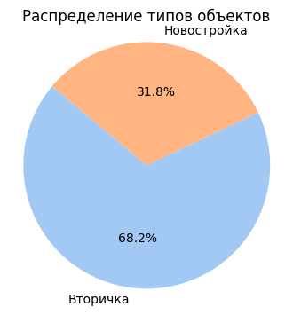

```python
grouped = flats.groupby('object_type').size().reset_index(name='count')

plt.figure(figsize=(4, 4))
sns.set_palette("pastel")
plt.title('Распределение типов объектов')

plt.pie(grouped['count'], labels=grouped['object_type'], autopct="%1.1f%%", startangle=140)
plt.axis('equal')

plt.show()
```

#### тип дома

```python
flats['type_of_house'].unique()
```

```
array([nan, 'Панельный', 'Монолитный', 'Кирпичный', 'Другое', 'Блочный',
       'Деревянный'], dtype=object)
```

заменим пропуски на 'Другое'

```python
flats['type_of_house'] = flats['type_of_house'].fillna('Другое')
```

```python
flats['type_of_house'].unique()
```

```
array(['Другое', 'Панельный', 'Монолитный', 'Кирпичный', 'Блочный',
       'Деревянный'], dtype=object)
```

```python
# Группировка данных по типу дома и подсчет их размера
grouped = flats.groupby('type_of_house').size().reset_index(name='count')
grouped
```

|  | type_of_house | count |
| --- | --- | --- |
| 0 | Блочный | 766 |
| 1 | Деревянный | 64 |
| 2 | Другое | 62759 |
| 3 | Кирпичный | 20673 |
| 4 | Монолитный | 4617 |
| 5 | Панельный | 43595 |

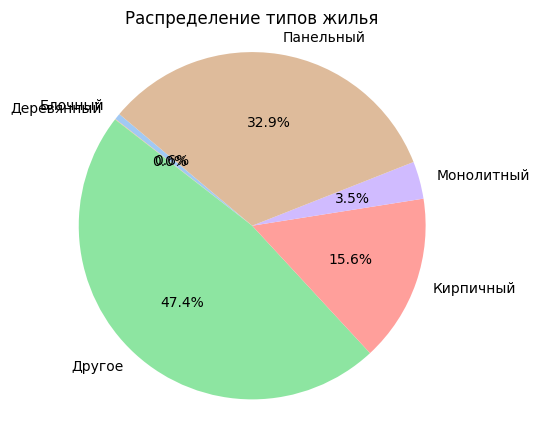

```python
plt.figure(figsize=(5, 5))
sns.set_palette("pastel")
plt.title('Распределение типов жилья')

plt.pie(grouped['count'], labels=grouped['type_of_house'], autopct="%1.1f%%", startangle=140)
plt.axis('equal')

plt.show()
```

#### тип этажа

```python
counts = flats[['floor_first','floor_last']].apply(pd.Series.value_counts)
```

```python
counts
```

|  | floor_first | floor_last |
| --- | --- | --- |
| False | 93070 | 95001 |
| True | 14168 | 12234 |

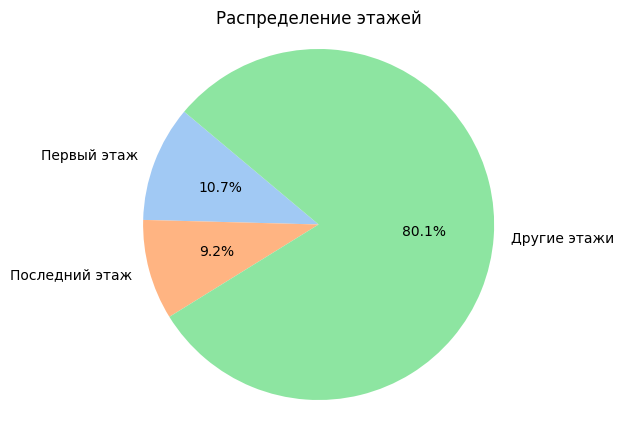

```python
first_floor_count = flats['floor_first'].sum()
last_floor_count = flats['floor_last'].sum()
other_floor_count = len(flats) - first_floor_count - last_floor_count

plt.figure(figsize=(5, 5))
sns.set_palette("pastel")
plt.pie([first_floor_count, last_floor_count, other_floor_count], labels=['Первый этаж', 'Последний этаж', 'Другие этажи']\
        , autopct='%1.1f%%', startangle=140)
plt.title('Распределение этажей')
plt.axis('equal')
plt.show()
```

#### пропуски, тип данных

```python
flats.isna().sum()
```

```
square_kitchen    27953
rooms             26559
object_type           0
square            25242
type_of_house         0
lat                   0
lng                   0
price                 0
floor_first       25236
floor_last        25239
dtype: int64
```

Удалим пропуски с отсутвием информации о площади кваритиры (без этой информации сложно судить о цене)

```python
flats.dropna(subset=['square'], inplace=True)
```

```python
flats.isna().sum()
```

```
square_kitchen    2714
rooms             1324
object_type          0
square               0
type_of_house        0
lat                  0
lng                  0
price                0
floor_first          1
floor_last           4
dtype: int64
```

Заполним пропуски "False" - первый/последний этаж

```python
flats['floor_first'] = flats['floor_first'].fillna(False)
flats['floor_last'] = flats['floor_last'].fillna(False)
```

```python
flats.info()
```

```
<class 'pandas.core.frame.DataFrame'>
Index: 107232 entries, 0 to 132473
Data columns (total 10 columns):
 #   Column          Non-Null Count   Dtype
---  ------          --------------   -----
 0   square_kitchen  104518 non-null  object
 1   rooms           105908 non-null  object
 2   object_type     107232 non-null  object
 3   square          107232 non-null  object
 4   type_of_house   107232 non-null  object
 5   lat             107232 non-null  float64
 6   lng             107232 non-null  float64
 7   price           107232 non-null  int64
 8   floor_first     107232 non-null  boolean
 9   floor_last      107232 non-null  boolean
dtypes: boolean(2), float64(2), int64(1), object(5)
memory usage: 7.8+ MB
```

```python
flats['square'] = flats['square'].astype('float')
```

#### количество комнат

Сгруппируем данные по количеству комнат и найдем среднюю площадь.

```python
data_grouped = flats.groupby('rooms')['square'].mean().reset_index()
data_grouped
```

|  | rooms | square |
| --- | --- | --- |
| 0 | 0 | 31.369048 |
| 1 | 1 | 37.159445 |
| 2 | 2 | 56.091237 |
| 3 | 3 | 76.807929 |
| 4 | 4 | 102.824006 |
| 5 | 5 | 175.936959 |
| 6 | 6 | 200.533200 |
| 7 | 7 | 91.123273 |
| 8 | 8 | 330.000000 |
| 9 | 9 | 273.600000 |
| 10 | Студия | 31.908713 |

Заменим "Студия" на rooms = 0.

```python
flats.loc[flats['rooms'] == 'Студия', 'rooms'] = '0'
```

```python
data_grouped = flats.groupby('rooms')['square'].mean().reset_index()
data_grouped
```

|  | rooms | square |
| --- | --- | --- |
| 0 | 0 | 31.892630 |
| 1 | 1 | 37.159445 |
| 2 | 2 | 56.091237 |
| 3 | 3 | 76.807929 |
| 4 | 4 | 102.824006 |
| 5 | 5 | 175.936959 |
| 6 | 6 | 200.533200 |
| 7 | 7 | 91.123273 |
| 8 | 8 | 330.000000 |
| 9 | 9 | 273.600000 |

Там, где комнат 7, сильно выбивается площадь:

```python
flats.loc[flats['rooms'] == '7'].head(10)
```

|  | square_kitchen | rooms | object_type | square | type_of_house | lat | lng | price | floor_first | floor_last |
| --- | --- | --- | --- | --- | --- | --- | --- | --- | --- | --- |
| 8081 | 0 | 7 | Новостройка | 39.86 | Другое | 55.037334 | 82.913638 | 3740850 | False | False |
| 8796 | 0 | 7 | Новостройка | 39.19 | Другое | 55.037334 | 82.913638 | 4062200 | False | False |
| 8905 | 12 | 7 | Вторичка | 272.00 | Другое | 55.020693 | 82.947613 | 12250000 | False | False |
| 11339 | 6 | 7 | Вторичка | 30.00 | Другое | 54.989083 | 82.892663 | 2450000 | False | False |
| 11520 | 0 | 7 | Вторичка | 169.00 | Другое | 55.026711 | 82.935602 | 16000000 | False | False |
| 13888 | 0 | 7 | Новостройка | 22.00 | Другое | 55.030431 | 82.942699 | 1330000 | False | False |
| 17844 | 0 | 7 | Новостройка | 66.21 | Другое | 55.037334 | 82.913638 | 7164150 | False | False |
| 17962 | 7 | 7 | Новостройка | 70.00 | Другое | 55.016767 | 82.939184 | 6488000 | False | False |
| 20260 | 0 | 7 | Новостройка | 45.03 | Другое | 55.028362 | 82.992097 | 2400000 | False | False |
| 30330 | 12 | 7 | Вторичка | 46.00 | Другое | 54.996758 | 82.906299 | 2750000 | False | False |

Там, где `square_kitchen` = 0 заменим на rooms = 0 - скорее всего, - это студия.

```python
flats.loc[flats['square_kitchen'] == '0', 'rooms'] = '0'
```

```python
data_grouped = flats.groupby('rooms')['square'].mean().reset_index()
data_grouped
```

|  | rooms | square |
| --- | --- | --- |
| 0 | 0 | 44.179407 |
| 1 | 1 | 38.032473 |
| 2 | 2 | 56.241798 |
| 3 | 3 | 76.650721 |
| 4 | 4 | 101.487316 |
| 5 | 5 | 170.548342 |
| 6 | 6 | 200.146111 |
| 7 | 7 | 91.763158 |
| 8 | 8 | 330.000000 |
| 9 | 9 | 273.600000 |

```python
flats.loc[flats['rooms'] == '7'].head(10)
```

|  | square_kitchen | rooms | object_type | square | type_of_house | lat | lng | price | floor_first | floor_last |
| --- | --- | --- | --- | --- | --- | --- | --- | --- | --- | --- |
| 8905 | 12 | 7 | Вторичка | 272.0 | Другое | 55.020693 | 82.947613 | 12250000 | False | False |
| 11339 | 6 | 7 | Вторичка | 30.0 | Другое | 54.989083 | 82.892663 | 2450000 | False | False |
| 17962 | 7 | 7 | Новостройка | 70.0 | Другое | 55.016767 | 82.939184 | 6488000 | False | False |
| 30330 | 12 | 7 | Вторичка | 46.0 | Другое | 54.996758 | 82.906299 | 2750000 | False | False |
| 53291 | 7 | 7 | Вторичка | 33.0 | Другое | 54.933988 | 82.923134 | 1690000 | False | False |
| 63514 | 15 | 7 | Вторичка | 62.0 | Другое | 54.868389 | 83.099581 | 4800000 | False | True |
| 64146 | 9 | 7 | Новостройка | 49.0 | Другое | 54.940748 | 83.117763 | 2011000 | False | False |
| 64148 | 2 | 7 | Новостройка | 35.0 | Другое | 54.861659 | 82.994627 | 1500000 | False | False |
| 67762 | 10 | 7 | Вторичка | 45.0 | Другое | 55.178367 | 82.961033 | 2250000 | False | True |
| 67770 | 13 | 7 | Вторичка | 135.0 | Другое | 55.054857 | 82.911554 | 9999000 | True | False |

Маленькой площадью, 7 комнатные квартиры, по низкой цене. Тут явно ошибка. Заменим количество комнат на количество, соответвующее площади. Возможно, имеется ввиду комната в коммунальной квартире.

```python
flats.loc[(flats['rooms'] == '7') & (flats['square'] < 47), 'rooms'] = '1'
flats.loc[(flats['rooms'] == '7') & (flats['square'] < 66), 'rooms'] = '2'
flats.loc[(flats['rooms'] == '7') & (flats['square'] < 88), 'rooms'] = '3'
flats.loc[(flats['rooms'] == '7') & (flats['square'] < 136), 'rooms'] = '4'
flats.loc[(flats['rooms'] == '7') & (flats['square'] < 185), 'rooms'] = '5'
```

```python
flats.loc[flats['rooms'] == '7'].head()
```

|  | square_kitchen | rooms | object_type | square | type_of_house | lat | lng | price | floor_first | floor_last |
| --- | --- | --- | --- | --- | --- | --- | --- | --- | --- | --- |
| 8905 | 12 | 7 | Вторичка | 272.0 | Другое | 55.020693 | 82.947613 | 12250000 | False | False |
| 81022 | 21 | 7 | Вторичка | 324.0 | Другое | 55.057084 | 82.910638 | 41000000 | False | True |
| 123690 | 39 | 7 | Новостройка | 240.0 | Кирпичный | 54.930434 | 82.985764 | 10900000 | False | False |

```python
data_grouped = flats.groupby('rooms')[['square','price']].mean().reset_index()
data_grouped
```

|  | rooms | square | price |
| --- | --- | --- | --- |
| 0 | 0 | 44.179407 | 2.904657e+06 |
| 1 | 1 | 38.032535 | 4.143363e+06 |
| 2 | 2 | 56.241056 | 3.098859e+06 |
| 3 | 3 | 76.649588 | 6.000799e+06 |
| 4 | 4 | 101.527835 | 7.019650e+06 |
| 5 | 5 | 170.362646 | 1.441242e+07 |
| 6 | 6 | 200.146111 | 1.608100e+07 |
| 7 | 7 | 278.666667 | 2.138333e+07 |
| 8 | 8 | 330.000000 | 2.350000e+07 |
| 9 | 9 | 273.600000 | 9.026000e+06 |

```python
flats.loc[flats['rooms'] == '9'].head()
```

|  | square_kitchen | rooms | object_type | square | type_of_house | lat | lng | price | floor_first | floor_last |
| --- | --- | --- | --- | --- | --- | --- | --- | --- | --- | --- |
| 81597 | 11.8 | 9 | Вторичка | 273.6 | Кирпичный | 54.893985 | 83.098673 | 9026000 | False | False |

```python
flats.isna().sum()
```

```
square_kitchen    2714
rooms             1324
object_type          0
square               0
type_of_house        0
lat                  0
lng                  0
price                0
floor_first          0
floor_last           0
dtype: int64
```

Заменим пропущенное количество комнат, количеством комнат, характерным для данной площади.

```python
data_grouped = flats.groupby('rooms')['square'].mean().reset_index()

characteristic_rooms = dict(zip(data_grouped['rooms'], data_grouped['square']))
characteristic_rooms
```

```
{'0': 44.179407188647986,
 '1': 38.032535376804105,
 '2': 56.241056196501674,
 '3': 76.64958774261498,
 '4': 101.52783545974482,
 '5': 170.3626455026455,
 '6': 200.1461111111111,
 '7': 278.6666666666667,
 '8': 330.0,
 '9': 273.6}
```

```python
characteristic_rooms = {key: float(value) for key, value in characteristic_rooms.items()}
```

```python
type(characteristic_rooms['1'])
```

```
float
```

```python
def replace_nan_rooms(row):
    if pd.isnull(row['rooms']):
        closest_key = min(characteristic_rooms, key=lambda x: abs(characteristic_rooms[x] - row['square']))
        return closest_key
    else:
        return row['rooms']

flats['rooms'] = flats.apply(replace_nan_rooms, axis=1)
```

```python
flats.isna().sum()
```

```
square_kitchen    2714
rooms                0
object_type          0
square               0
type_of_house        0
lat                  0
lng                  0
price                0
floor_first          0
floor_last           0
dtype: int64
```

```python
flats['rooms'] = flats['rooms'].astype('int')
```

```python
room_counts = flats['rooms'].value_counts().sort_index()
pd.DataFrame({'Количество комнат': room_counts.index, 'Частота': room_counts.values})
```

|  | Количество комнат | Частота |
| --- | --- | --- |
| 0 | 0 | 14108 |
| 1 | 1 | 43202 |
| 2 | 2 | 27128 |
| 3 | 3 | 20056 |
| 4 | 4 | 2328 |
| 5 | 5 | 386 |
| 6 | 6 | 19 |
| 7 | 7 | 3 |
| 8 | 8 | 1 |
| 9 | 9 | 1 |

Оставим только квартиры с количеством комнат < 6.

```python
flats = flats.loc[flats['rooms'] < 6]
flats.head()
```

|  | square_kitchen | rooms | object_type | square | type_of_house | lat | lng | price | floor_first | floor_last |
| --- | --- | --- | --- | --- | --- | --- | --- | --- | --- | --- |
| 0 | 25 | 2 | Вторичка | 64.0 | Другое | 55.012749 | 83.001835 | 2050000 | False | False |
| 1 | 8.3 | 1 | Вторичка | 35.3 | Другое | 55.024389 | 82.910773 | 2550000 | False | False |
| 2 | 7 | 2 | Вторичка | 54.5 | Другое | 54.985349 | 82.863854 | 2280000 | False | False |
| 3 | NaN | 2 | Вторичка | 44.6 | Другое | 54.870927 | 83.096688 | 2300000 | True | False |
| 4 | 8 | 2 | Вторичка | 57.0 | Другое | 55.112005 | 82.938064 | 3280000 | False | False |

#### площадь кухни

```python
flats.isna().sum()
```

```
square_kitchen    2713
rooms                0
object_type          0
square               0
type_of_house        0
lat                  0
lng                  0
price                0
floor_first          0
floor_last           0
dtype: int64
```

там, где площадь кухни = NaN, и, где студия, - заменим площадь на 0.

```python
flats.loc[(flats['square_kitchen'].isna()) & (flats['rooms'] == 0)].head()
```

|  | square_kitchen | rooms | object_type | square | type_of_house | lat | lng | price | floor_first | floor_last |
| --- | --- | --- | --- | --- | --- | --- | --- | --- | --- | --- |
| 26 | NaN | 0 | Новостройка | 61.4 | Кирпичный | 55.014526 | 82.889773 | 3812333 | False | False |
| 28 | NaN | 0 | Вторичка | 16.0 | Панельный | 55.012749 | 83.001835 | 1030000 | False | False |
| 206 | NaN | 0 | Новостройка | 33.0 | Панельный | 54.944957 | 82.962740 | 1200000 | False | False |
| 345 | NaN | 0 | Новостройка | 27.4 | Кирпичный | 55.046455 | 82.865794 | 1650000 | False | False |
| 367 | NaN | 0 | Вторичка | 30.0 | Кирпичный | 55.034184 | 83.022276 | 2250000 | False | False |

```python
flats.loc[(flats['square_kitchen'].isna()) & (flats['rooms'] == 0), 'square_kitchen'] = 0
```

проверим, что у нас нулевая площадь только в студиях:

```python
flats.loc[(flats['square_kitchen'] == 0)]['rooms'].unique()
```

```
array([0])
```

заменим, все оставшиеся NaN, на типичную долю от площади квартиры.

```python
flats.isna().sum()
```

```
square_kitchen    2336
rooms                0
object_type          0
square               0
type_of_house        0
lat                  0
lng                  0
price                0
floor_first          0
floor_last           0
dtype: int64
```

```python
data_cleaned = flats.dropna(subset=['square_kitchen']).copy()
data_cleaned['square_kitchen'] = data_cleaned['square_kitchen'].astype(float)

data_grouped = data_cleaned.groupby('rooms')[['square','square_kitchen']].mean().reset_index()

data_grouped
```

|  | rooms | square | square_kitchen |
| --- | --- | --- | --- |
| 0 | 0 | 44.188560 | 0.643460 |
| 1 | 1 | 38.068303 | 8.487212 |
| 2 | 2 | 56.297475 | 11.579104 |
| 3 | 3 | 76.547061 | 11.333316 |
| 4 | 4 | 101.554572 | 14.281772 |
| 5 | 5 | 170.426973 | 19.249676 |

Посмотрим, где для студии не нулевая площадь кухни.

```python
data_cleaned.loc[(data_cleaned['square_kitchen'] > 0) & (data_cleaned['rooms'] == 0)].head()
```

|  | square_kitchen | rooms | object_type | square | type_of_house | lat | lng | price | floor_first | floor_last |
| --- | --- | --- | --- | --- | --- | --- | --- | --- | --- | --- |
| 509 | 10.8 | 0 | Вторичка | 41.3 | Другое | 54.947020 | 82.972235 | 1195000 | False | False |
| 666 | 20.1 | 0 | Вторичка | 43.5 | Другое | 54.991057 | 82.917043 | 4000000 | False | False |
| 686 | 22.0 | 0 | Вторичка | 44.0 | Другое | 55.047451 | 82.862363 | 3750000 | False | False |
| 1132 | 5.1 | 0 | Вторичка | 37.4 | Кирпичный | 54.940556 | 82.883895 | 1650000 | False | False |
| 2114 | 18.0 | 0 | Вторичка | 37.5 | Кирпичный | 55.124738 | 82.904368 | 2800000 | False | False |

Занулим эти площади.

```python
data_cleaned.loc[data_cleaned['rooms'] == 0, 'square_kitchen'] = 0
```

```python
data_cleaned.loc[(data_cleaned['square_kitchen'] > 0) & (data_cleaned['rooms'] == 0)].head()
```

|  | square_kitchen | rooms | object_type | square | type_of_house | lat | lng | price | floor_first | floor_last |
| --- | --- | --- | --- | --- | --- | --- | --- | --- | --- | --- |

```python
data_grouped = data_cleaned.groupby('rooms')[['square','square_kitchen']].mean().reset_index()

data_grouped
```

|  | rooms | square | square_kitchen |
| --- | --- | --- | --- |
| 0 | 0 | 44.188560 | 0.000000 |
| 1 | 1 | 38.068303 | 8.487212 |
| 2 | 2 | 56.297475 | 11.579104 |
| 3 | 3 | 76.547061 | 11.333316 |
| 4 | 4 | 101.554572 | 14.281772 |
| 5 | 5 | 170.426973 | 19.249676 |

создадим столбец с долей площади кухни от общей площади для разного количества комнат

```python
data_grouped['part_of_kitchen'] = data_grouped['square_kitchen']/data_grouped['square']
```

```python
data_grouped
```

|  | rooms | square | square_kitchen | part_of_kitchen |
| --- | --- | --- | --- | --- |
| 0 | 0 | 44.188560 | 0.000000 | 0.000000 |
| 1 | 1 | 38.068303 | 8.487212 | 0.222947 |
| 2 | 2 | 56.297475 | 11.579104 | 0.205677 |
| 3 | 3 | 76.547061 | 11.333316 | 0.148057 |
| 4 | 4 | 101.554572 | 14.281772 | 0.140632 |
| 5 | 5 | 170.426973 | 19.249676 | 0.112950 |

заменим пропуски с площадью кухни, умножив площадь на коэффиент, характерный для группы по количеству комнат.

```python
charact_koef = dict(zip(data_grouped['rooms'], data_grouped['part_of_kitchen']))
charact_koef
```

```
{0: 0.0,
 1: 0.22294694446065788,
 2: 0.20567715643233056,
 3: 0.14805684459532126,
 4: 0.14063150403516586,
 5: 0.11294970121148822}
```

```python
def square_kitchen(row):
    if pd.isnull(row['square_kitchen']):
        num_rooms = row['rooms']
        if num_rooms in charact_koef:
            koef = charact_koef[num_rooms]
            square_kitchen = row['square'] * koef
            return square_kitchen
    return row['square_kitchen']

flats['square_kitchen'] = flats.apply(square_kitchen, axis=1)
```

```python
flats.isna().sum()
```

```
square_kitchen    0
rooms             0
object_type       0
square            0
type_of_house     0
lat               0
lng               0
price             0
floor_first       0
floor_last        0
dtype: int64
```

```python
flats['square_kitchen'] = flats['square_kitchen'].astype(float)
data_grouped = flats.groupby('rooms')[['square','square_kitchen']].mean().reset_index()
data_grouped
```

|  | rooms | square | square_kitchen |
| --- | --- | --- | --- |
| 0 | 0 | 44.188560 | 0.643460 |
| 1 | 1 | 37.937452 | 8.458039 |
| 2 | 2 | 56.267638 | 11.572968 |
| 3 | 3 | 76.655775 | 11.349412 |
| 4 | 4 | 101.759695 | 14.310619 |
| 5 | 5 | 169.860311 | 19.185671 |

```python
data_cleaned.loc[data_cleaned['rooms'] == 0, 'square_kitchen'] = 0
```

```python
flats.info()
```

```
<class 'pandas.core.frame.DataFrame'>
Index: 107208 entries, 0 to 132473
Data columns (total 10 columns):
 #   Column          Non-Null Count   Dtype
---  ------          --------------   -----
 0   square_kitchen  107208 non-null  float64
 1   rooms           107208 non-null  int32
 2   object_type     107208 non-null  object
 3   square          107208 non-null  float64
 4   type_of_house   107208 non-null  object
 5   lat             107208 non-null  float64
 6   lng             107208 non-null  float64
 7   price           107208 non-null  int64
 8   floor_first     107208 non-null  boolean
 9   floor_last      107208 non-null  boolean
dtypes: boolean(2), float64(4), int32(1), int64(1), object(2)
memory usage: 7.4+ MB
```

```python
data_grouped = flats.groupby('rooms')[['square','square_kitchen']].mean().reset_index()
data_grouped
```

|  | rooms | square | square_kitchen |
| --- | --- | --- | --- |
| 0 | 0 | 44.188560 | 0.643460 |
| 1 | 1 | 37.937452 | 8.458039 |
| 2 | 2 | 56.267638 | 11.572968 |
| 3 | 3 | 76.655775 | 11.349412 |
| 4 | 4 | 101.759695 | 14.310619 |
| 5 | 5 | 169.860311 | 19.185671 |

#### выбросы, дубликаты

```python
flats.head()
```

|  | square_kitchen | rooms | object_type | square | type_of_house | lat | lng | price | floor_first | floor_last |
| --- | --- | --- | --- | --- | --- | --- | --- | --- | --- | --- |
| 0 | 25.000000 | 2 | Вторичка | 64.0 | Другое | 55.012749 | 83.001835 | 2050000 | False | False |
| 1 | 8.300000 | 1 | Вторичка | 35.3 | Другое | 55.024389 | 82.910773 | 2550000 | False | False |
| 2 | 7.000000 | 2 | Вторичка | 54.5 | Другое | 54.985349 | 82.863854 | 2280000 | False | False |
| 3 | 9.173201 | 2 | Вторичка | 44.6 | Другое | 54.870927 | 83.096688 | 2300000 | True | False |
| 4 | 8.000000 | 2 | Вторичка | 57.0 | Другое | 55.112005 | 82.938064 | 3280000 | False | False |

```python
print('Количество дубликатов в данных:', flats.duplicated().sum())
```

```
Количество дубликатов в данных: 51633
```

```python
flats = flats.drop_duplicates()
```

```python
# стат. показатели для проверки на выбросы, аномалии
flats.describe(include='all')
```

|  | square_kitchen | rooms | object_type | square | type_of_house | lat | lng | price | floor_first | floor_last |
| --- | --- | --- | --- | --- | --- | --- | --- | --- | --- | --- |
| count | 55575.000000 | 55575.000000 | 55575 | 55575.000000 | 55575 | 55575.000000 | 55575.000000 | 5.557500e+04 | 55575 | 55575 |
| unique | NaN | NaN | 2 | NaN | 6 | NaN | NaN | NaN | 2 | 2 |
| top | NaN | NaN | Вторичка | NaN | Другое | NaN | NaN | NaN | False | False |
| freq | NaN | NaN | 41187 | NaN | 28747 | NaN | NaN | NaN | 49291 | 48948 |
| mean | 9.077882 | 1.593648 | NaN | 53.336475 | NaN | 51.410812 | 77.504030 | 3.478244e+06 | NaN | NaN |
| std | 181.751298 | 1.094521 | NaN | 27.196652 | NaN | 13.609415 | 20.523543 | 1.407164e+07 | NaN | NaN |
| min | 0.000000 | 0.000000 | NaN | 0.000000 | NaN | 0.000000 | 0.000000 | 1.030000e+03 | NaN | NaN |
| 25% | 5.000000 | 1.000000 | NaN | 36.795000 | NaN | 54.955856 | 82.893893 | 1.924000e+06 | NaN | NaN |
| 50% | 8.000000 | 2.000000 | NaN | 46.000000 | NaN | 55.008536 | 82.935710 | 2.699000e+06 | NaN | NaN |
| 75% | 11.000000 | 2.000000 | NaN | 63.130000 | NaN | 55.044913 | 82.971917 | 3.800000e+06 | NaN | NaN |
| max | 42831.000000 | 5.000000 | NaN | 813.000000 | NaN | 83.086645 | 83.432611 | 2.036187e+09 | NaN | NaN |

##### широта, долгота

*Ограничимся:*

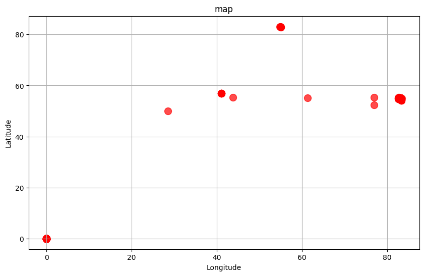

```python
plt.figure(figsize=(10, 6))
plt.scatter(flats['lng'], flats['lat'], color='red', s=100, alpha=0.7)
plt.xlabel('Longitude')
plt.ylabel('Latitude')
plt.title('map')
plt.grid(True)
plt.show()  #
```

```python
flats.loc[flats['lat'] > 57.0614]
```

|  | square_kitchen | rooms | object_type | square | type_of_house | lat | lng | price | floor_first | floor_last |
| --- | --- | --- | --- | --- | --- | --- | --- | --- | --- | --- |
| 38724 | 5.573674 | 1 | Вторичка | 25.0 | Кирпичный | 82.873591 | 55.042561 | 950000 | True | False |
| 54642 | 7.290365 | 1 | Вторичка | 32.7 | Кирпичный | 83.080554 | 55.048606 | 1600000 | False | False |
| 61515 | 8.967524 | 2 | Вторичка | 43.6 | Кирпичный | 83.086645 | 54.863202 | 2300000 | True | False |
| 75453 | 12.555220 | 3 | Вторичка | 84.8 | Кирпичный | 82.920016 | 55.022288 | 7800000 | False | True |
| 119130 | 12.176088 | 2 | Вторичка | 59.2 | Панельный | 82.983680 | 54.921567 | 4500000 | True | False |

*- в нескольких местах, по-видимому, перепутаны `lat` и `lng` - поменяем местами;*

```python
flats.loc[flats['lat'] > 57.0614, ['lat', 'lng']] = flats.loc[flats['lat'] > 57.0614, ['lng', 'lat']].values
```

```python
flats.loc[flats['lng'] < 75.9284].head()
```

|  | square_kitchen | rooms | object_type | square | type_of_house | lat | lng | price | floor_first | floor_last |
| --- | --- | --- | --- | --- | --- | --- | --- | --- | --- | --- |
| 75 | 0.00 | 0 | Новостройка | 23.09 | Другое | 0.0 | 0.0 | 1177590 | False | False |
| 86 | 8.00 | 1 | Вторичка | 36.00 | Панельный | 0.0 | 0.0 | 1850000 | False | False |
| 96 | 9.62 | 1 | Вторичка | 32.30 | Другое | 0.0 | 0.0 | 2450000 | False | False |
| 103 | 11.00 | 2 | Вторичка | 53.00 | Кирпичный | 0.0 | 0.0 | 2050000 | False | False |
| 104 | 12.60 | 2 | Новостройка | 64.50 | Другое | 0.0 | 0.0 | 5800000 | False | False |

```python
flats = flats[flats['lng'] > 0]
```

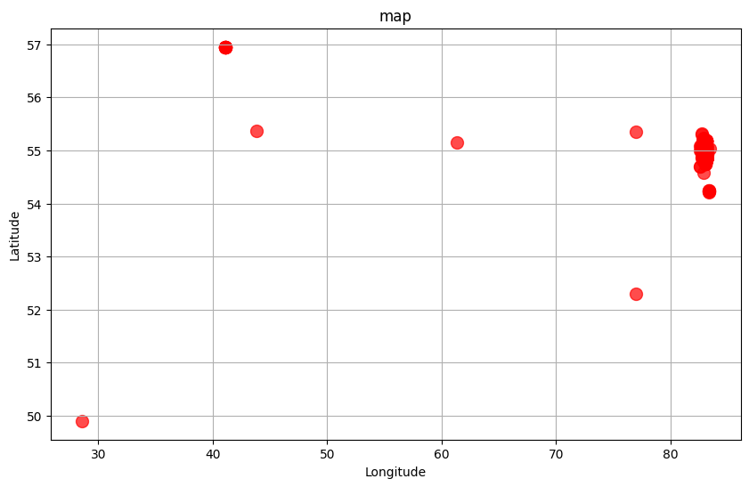

```python
plt.figure(figsize=(10, 6))
plt.scatter(flats['lng'], flats['lat'], color='red', s=100, alpha=0.7)
plt.xlabel('Longitude')
plt.ylabel('Latitude')
plt.title('map')
plt.grid(True)
plt.show()  #
```

*и сделаем срез для Новосибирской области по долготе и широте*

```python
flats = flats[(flats['lat'] >= 54.63) & (flats['lat'] <= 55.33) &\
                    (flats['lng'] >= 82.5) & (flats['lng'] <= 83.4)]
```

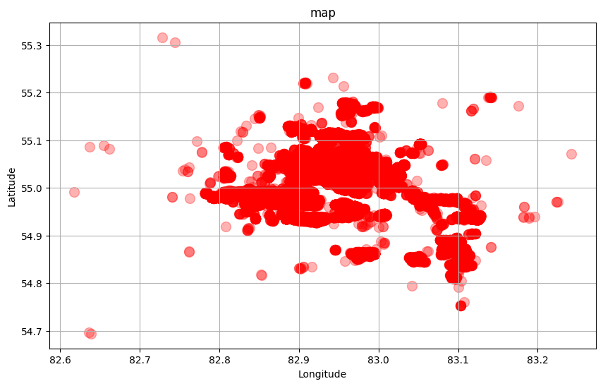

```python
plt.figure(figsize=(10, 6))
plt.scatter(flats['lng'], flats['lat'], color='red', s=100, alpha=0.3)
plt.xlabel('Longitude')
plt.ylabel('Latitude')
plt.title('map')
plt.grid(True)
plt.show()  #
```

##### стоимость, площадь

Построим сводную таблицу для групп по количеству комнат: средние значения площади, площади кухни, цены

```python
data_grouped = flats.groupby('rooms')[['square','square_kitchen','price']].mean().reset_index()
data_grouped
```

|  | rooms | square | square_kitchen | price |
| --- | --- | --- | --- | --- |
| 0 | 0 | 45.811448 | 0.890275 | 3.163384e+06 |
| 1 | 1 | 36.535899 | 8.454774 | 2.241443e+06 |
| 2 | 2 | 54.704780 | 12.711903 | 3.423854e+06 |
| 3 | 3 | 76.488806 | 11.515561 | 4.720971e+06 |
| 4 | 4 | 100.518311 | 13.985892 | 6.941200e+06 |
| 5 | 5 | 166.213032 | 20.042213 | 1.322642e+07 |

```python
data_grouped = flats.groupby('rooms')[['square','square_kitchen','price']].mean().reset_index()
data_grouped
```

|  | rooms | square | square_kitchen | price |
| --- | --- | --- | --- | --- |
| 0 | 0 | 45.811448 | 0.890275 | 3.163384e+06 |
| 1 | 1 | 36.535899 | 8.454774 | 2.241443e+06 |
| 2 | 2 | 54.704780 | 12.711903 | 3.423854e+06 |
| 3 | 3 | 76.488806 | 11.515561 | 4.720971e+06 |
| 4 | 4 | 100.518311 | 13.985892 | 6.941200e+06 |
| 5 | 5 | 166.213032 | 20.042213 | 1.322642e+07 |

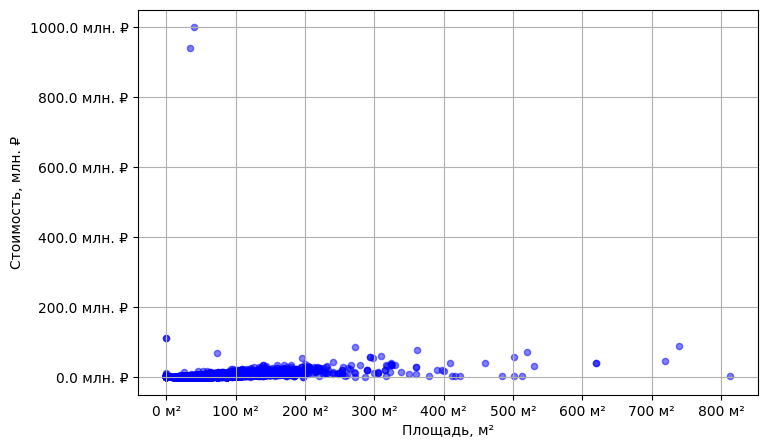

```python
ax = flats.plot(x='square', y='price', kind='scatter', alpha=0.5, grid = True, figsize = (8,5), color='blue')

ax.xaxis.set_major_formatter(plt.FuncFormatter(lambda x, _: f'{x:.0f} м²'))
ax.yaxis.set_major_formatter(plt.FuncFormatter(lambda y, _: f'{y / 1e6:.1f} млн. ₽'))

ax.set_xlabel('Площадь, м²')
ax.set_ylabel('Стоимость, млн. ₽');
```

```python
# стат. показатели для проверки на выбросы, аномалии
flats.describe()
```

|  | square_kitchen | rooms | square | lat | lng | price |
| --- | --- | --- | --- | --- | --- | --- |
| count | 51915.000000 | 51915.000000 | 51915.000000 | 51915.000000 | 51915.000000 | 5.191500e+04 |
| mean | 9.226342 | 1.624463 | 53.657369 | 55.009154 | 82.945240 | 3.409856e+06 |
| std | 188.041256 | 1.093154 | 27.450270 | 0.060892 | 0.067051 | 6.602786e+06 |
| min | 0.000000 | 0.000000 | 0.000000 | 54.693972 | 82.617721 | 1.030000e+03 |
| 25% | 5.200000 | 1.000000 | 37.000000 | 54.970861 | 82.900927 | 1.960000e+06 |
| 50% | 8.000000 | 2.000000 | 46.200000 | 55.015857 | 82.940031 | 2.700000e+06 |
| 75% | 11.000000 | 2.000000 | 63.500000 | 55.046997 | 82.973367 | 3.850000e+06 |
| max | 42831.000000 | 5.000000 | 813.000000 | 55.316446 | 83.241955 | 9.999999e+08 |

```python
flats = flats[(flats['price'] < 50*10**6) & (flats['square'] < 400)]
flats = flats[(flats['price'] > 2*10**6) & (flats['square'] > 27)]
```

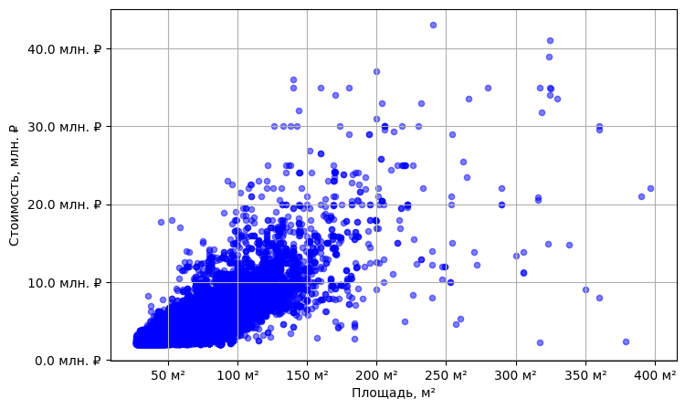

```python
ax = flats.plot(x='square', y='price', kind='scatter', alpha=0.5, grid = True, figsize = (8,5), color='blue')

ax.xaxis.set_major_formatter(plt.FuncFormatter(lambda x, _: f'{x:.0f} м²'))
ax.yaxis.set_major_formatter(plt.FuncFormatter(lambda y, _: f'{y / 1e6:.1f} млн. ₽'))

ax.set_xlabel('Площадь, м²')
ax.set_ylabel('Стоимость, млн. ₽');
```

```python
print('Корреляция между площадью и стоимостью квартиры', flats['price'].corr(flats['square']))
```

```
Корреляция между площадью и стоимостью квартиры 0.7939432975051901
```

### Итоговый вариант исходных данных

```python
flats = flats.reindex(columns=list(flats.columns.drop('price')) + ['price'])

flats.head()
```

|  | square_kitchen | rooms | object_type | square | type_of_house | lat | lng | floor_first | floor_last | price |
| --- | --- | --- | --- | --- | --- | --- | --- | --- | --- | --- |
| 0 | 25.000000 | 2 | Вторичка | 64.0 | Другое | 55.012749 | 83.001835 | False | False | 2050000 |
| 1 | 8.300000 | 1 | Вторичка | 35.3 | Другое | 55.024389 | 82.910773 | False | False | 2550000 |
| 2 | 7.000000 | 2 | Вторичка | 54.5 | Другое | 54.985349 | 82.863854 | False | False | 2280000 |
| 3 | 9.173201 | 2 | Вторичка | 44.6 | Другое | 54.870927 | 83.096688 | True | False | 2300000 |
| 4 | 8.000000 | 2 | Вторичка | 57.0 | Другое | 55.112005 | 82.938064 | False | False | 3280000 |

```python
flats.info()
```

```
<class 'pandas.core.frame.DataFrame'>
Index: 37566 entries, 0 to 132473
Data columns (total 10 columns):
 #   Column          Non-Null Count  Dtype
---  ------          --------------  -----
 0   square_kitchen  37566 non-null  float64
 1   rooms           37566 non-null  int32
 2   object_type     37566 non-null  object
 3   square          37566 non-null  float64
 4   type_of_house   37566 non-null  object
 5   lat             37566 non-null  float64
 6   lng             37566 non-null  float64
 7   floor_first     37566 non-null  boolean
 8   floor_last      37566 non-null  boolean
 9   price           37566 non-null  int64
dtypes: boolean(2), float64(4), int32(1), int64(1), object(2)
memory usage: 2.6+ MB
```

```python
print('Количество дубликатов в данных:', flats.duplicated().sum())
```

```
Количество дубликатов в данных: 0
```

```python
flats.isna().sum()
```

```
square_kitchen    0
rooms             0
object_type       0
square            0
type_of_house     0
lat               0
lng               0
floor_first       0
floor_last        0
price             0
dtype: int64
```

```python
flats.describe(include='all')
```

|  | square_kitchen | rooms | object_type | square | type_of_house | lat | lng | floor_first | floor_last | price |
| --- | --- | --- | --- | --- | --- | --- | --- | --- | --- | --- |
| count | 37566.000000 | 37566.000000 | 37566 | 37566.000000 | 37566 | 37566.000000 | 37566.000000 | 37566 | 37566 | 3.756600e+04 |
| unique | NaN | NaN | 2 | NaN | 6 | NaN | NaN | 2 | 2 | NaN |
| top | NaN | NaN | Вторичка | NaN | Другое | NaN | NaN | False | False | NaN |
| freq | NaN | NaN | 29800 | NaN | 20432 | NaN | NaN | 33869 | 33145 | NaN |
| mean | 10.662040 | 1.894053 | NaN | 60.676103 | NaN | 55.017546 | 82.941679 | NaN | NaN | 4.030362e+06 |
| std | 221.022268 | 1.086249 | NaN | 25.904755 | NaN | 0.058293 | 0.060825 | NaN | NaN | 2.580582e+06 |
| min | 0.000000 | 0.000000 | NaN | 27.100000 | NaN | 54.752157 | 82.761992 | NaN | NaN | 2.001510e+06 |
| 25% | 6.000000 | 1.000000 | NaN | 43.000000 | NaN | 54.986909 | 82.901637 | NaN | NaN | 2.580000e+06 |
| 50% | 9.000000 | 2.000000 | NaN | 56.000000 | NaN | 55.026633 | 82.935611 | NaN | NaN | 3.250000e+06 |
| 75% | 12.000000 | 3.000000 | NaN | 71.000000 | NaN | 55.050985 | 82.969945 | NaN | NaN | 4.490000e+06 |
| max | 42831.000000 | 5.000000 | NaN | 397.000000 | NaN | 55.220634 | 83.196132 | NaN | NaN | 4.300000e+07 |

### Промежуточный результат

```python
flats.to_csv(data_root /"transformed/data.csv", index=False)
```

- Из сырых данных `csv-8606.csv.bz2` (цены на квартиры в Новосибирске за 2019 год) были извлечены признаки flats, которые будем генерировать для синтетических данных:
- `square_kitchen` площадь кухни, м²
- `rooms` количество комнат
- `object_type` вид объекта (новостройка/вторичка)
- `square` площадь, м²
- `type_of_house` тип дома (кирпич, панельный и т.д.)
- `lat` широта
- `lng` долгота
- `price` стоимость объекта, руб;
- `floor_first` False/True
- `floor_last` False/True
- создан `flats` - dataset признаков и целевого признака.
- удалены дубликаты
- удалены/заменены пропущенные значения
- проверены типы данных
- проведен EDA
- удалены явные выбросы, анамалии
- заполены пропуски (для количества комнат и площади кухни - средними по группе)

## Геокодирование реестра многоквартирных домов

Проводим геокодирование реестра многоквартирных домов

```python
pd.options.display.max_columns = None
data_full = pd.read_table(data_root / 'export-reestrmkd-54-20240401.zip', sep=';',low_memory=False)
data_full.head()
```

|  | id | region_id | area_id | city_id | street_id | shortname_region | formalname_region | shortname_area | formalname_area | shortname_city | formalname_city | shortname_street | formalname_street | house_number | building | block | letter | address | houseguid | management_organization_id | built_year | exploitation_start_year | project_type | house_type | is_alarm | method_of_forming_overhaul_fund | floor_count_max | floor_count_min | entrance_count | … |
| --- | --- | --- | --- | --- | --- | --- | --- | --- | --- | --- | --- | --- | --- | --- | --- | --- | --- | --- | --- | --- | --- | --- | --- | --- | --- | --- | --- | --- | --- | --- |
| 0 | 6569955 | NaN | NaN | NaN | NaN | NaN | NaN | NaN | NaN | NaN | NaN | NaN | NaN | г.Новосибирск, ул. Забалуева, 51/2 (№ 3 строительный) | NaN | NaN | NaN | д. г.Новосибирск, ул. Забалуева, 51/2 (№ 3 строительный) | 8e3e3766-0831-6cf0-a143-fd798bc307d6 | 8508528.0 | 2009.0 | 2009.0 | 90-Н | Многоквартирный дом | Нет | На счете регионального оператора | 10.0 | 1.0 | 4.0 | … |
| 1 | 6569966 | NaN | NaN | NaN | NaN | NaN | NaN | NaN | NaN | NaN | NaN | NaN | NaN | г. Обь, ул. Чкалова,44( ул. Ломоносова, 46 -строительный) | NaN | NaN | NaN | д. г. Обь, ул. Чкалова,44( ул. Ломоносова, 46 -строительный) | 502788c2-306f-14c7-15cc-abaa463e1140 | NaN | NaN | 2009.0 | 90л-05.1 | Многоквартирный дом | Нет | Не заполнено | 11.0 | NaN | 4.0 | … |
| 2 | 9415691 | 1ac46b49-3209-4814-b7bf-a509ea1aecd9 | d0133369-2bb2-4497-992b-4448dbd7aa69 | 05b2da50-4114-4688-9b24-03be2d08c35d | b5d90ef9-c9d7-45aa-a68b-d9b5b6afbb0f | обл | Новосибирская | р-н | Баганский | с | Баган | ул | Вокзальная | 2 | NaN | NaN | NaN | обл. Новосибирская, р-н. Баганский, с. Баган, ул. Вокзальная, д. 2 | e102c6e5-32a0-4b65-ad97-f01122cfe45e | NaN | NaN | NaN | NaN | Не заполнено | Да | Не заполнено | NaN | NaN | NaN | … |
| 3 | 9183803 | 1ac46b49-3209-4814-b7bf-a509ea1aecd9 | d0133369-2bb2-4497-992b-4448dbd7aa69 | 05b2da50-4114-4688-9b24-03be2d08c35d | b5d90ef9-c9d7-45aa-a68b-d9b5b6afbb0f | обл | Новосибирская | р-н | Баганский | с | Баган | ул | Вокзальная | 20 | NaN | NaN | NaN | обл. Новосибирская, р-н. Баганский, с. Баган, ул. Вокзальная, д. 20 | 375b83a8-1a25-4b3d-878f-07530194bf65 | NaN | NaN | NaN | NaN | Не заполнено | Нет | Не заполнено | NaN | NaN | NaN | … |
| 4 | 9183797 | 1ac46b49-3209-4814-b7bf-a509ea1aecd9 | d0133369-2bb2-4497-992b-4448dbd7aa69 | 05b2da50-4114-4688-9b24-03be2d08c35d | b5d90ef9-c9d7-45aa-a68b-d9b5b6afbb0f | обл | Новосибирская | р-н | Баганский | с | Баган | ул | Вокзальная | 22 | NaN | NaN | NaN | обл. Новосибирская, р-н. Баганский, с. Баган, ул. Вокзальная, д. 22 | 9661a6a2-86f0-4fcb-8c7a-ebaf46139a4b | NaN | NaN | NaN | NaN | Не заполнено | Нет | Не заполнено | NaN | NaN | NaN | … |

```python
data_full.info()
```

```
<class 'pandas.core.frame.DataFrame'>
RangeIndex: 15145 entries, 0 to 15144
Data columns (total 60 columns):
 #   Column                           Non-Null Count  Dtype
---  ------                           --------------  -----
 0   id                               15145 non-null  int64
 1   region_id                        15143 non-null  object
 2   area_id                          4216 non-null   object
 3   city_id                          15143 non-null  object
 4   street_id                        14944 non-null  object
 5   shortname_region                 15143 non-null  object
 6   formalname_region                15143 non-null  object
 7   shortname_area                   4216 non-null   object
 8   formalname_area                  4216 non-null   object
 9   shortname_city                   15143 non-null  object
```

[output cut: 52 more lines]

```python
data_full = data_full.query('formalname_city == "Краснообск" or formalname_city == "Новосибирск"')
print('Размер среза данных по городам:',  data_full.shape)
```

```
Размер среза данных по городам: (8629, 60)
```

```python
data_full = data_full.reset_index()
data_full.head()
```

|  | index | id | region_id | area_id | city_id | street_id | shortname_region | formalname_region | shortname_area | formalname_area | shortname_city | formalname_city | shortname_street | formalname_street | house_number | building | block | letter | address | houseguid | management_organization_id | built_year | exploitation_start_year | project_type | house_type | is_alarm | method_of_forming_overhaul_fund | floor_count_max | floor_count_min | … |
| --- | --- | --- | --- | --- | --- | --- | --- | --- | --- | --- | --- | --- | --- | --- | --- | --- | --- | --- | --- | --- | --- | --- | --- | --- | --- | --- | --- | --- | --- | --- |
| 0 | 4293 | 8566678 | 1ac46b49-3209-4814-b7bf-a509ea1aecd9 | NaN | 8dea00e3-9aab-4d8e-887c-ef2aaa546456 | 4dfccdc0-6e03-4691-b9dc-ff3011df87fe | обл | Новосибирская | NaN | NaN | г | Новосибирск | ул | 1905 года | 2 | NaN | NaN | NaN | обл. Новосибирская, г. Новосибирск, ул. 1905 года, д. 2 | 919292fd-de79-4a25-b7ad-5a89dd18e9b5 | 8566728.0 | 1998.0 | 1998.0 | НКЖ АР007.94-1 жилой дом | Многоквартирный дом | Нет | На специальном счете организации | 10.0 | 10.0 | … |
| 1 | 4294 | 8582397 | 1ac46b49-3209-4814-b7bf-a509ea1aecd9 | NaN | 8dea00e3-9aab-4d8e-887c-ef2aaa546456 | 4dfccdc0-6e03-4691-b9dc-ff3011df87fe | обл | Новосибирская | NaN | NaN | г | Новосибирск | ул | 1905 года | 17/1 | NaN | NaN | NaN | обл. Новосибирская, г. Новосибирск, ул. 1905 года, д. 17/1 | 928df284-09fb-4e74-b8f0-f5afbe6ef4cc | NaN | NaN | 1994.0 | 97 | Многоквартирный дом | Нет | На специальном счете организации | 13.0 | NaN | … |
| 2 | 4295 | 8582398 | 1ac46b49-3209-4814-b7bf-a509ea1aecd9 | NaN | 8dea00e3-9aab-4d8e-887c-ef2aaa546456 | 4dfccdc0-6e03-4691-b9dc-ff3011df87fe | обл | Новосибирская | NaN | NaN | г | Новосибирск | ул | 1905 года | 17/2 | NaN | NaN | NaN | обл. Новосибирская, г. Новосибирск, ул. 1905 года, д. 17/2 | 5199093c-3cf3-4d15-8c13-e338c35e1428 | 8348926.0 | NaN | 1994.0 | 97 | Многоквартирный дом | Нет | На специальном счете организации | 13.0 | NaN | … |
| 3 | 4296 | 7745366 | 1ac46b49-3209-4814-b7bf-a509ea1aecd9 | NaN | 8dea00e3-9aab-4d8e-887c-ef2aaa546456 | 4dfccdc0-6e03-4691-b9dc-ff3011df87fe | обл | Новосибирская | NaN | NaN | г | Новосибирск | ул | 1905 года | 18 | NaN | NaN | NaN | обл. Новосибирская, г. Новосибирск, ул. 1905 года, д. 18 | 25643fe4-fb4b-4534-a26e-d40fd2631a62 | 7648925.0 | 1975.0 | 1975.0 | 1-448 (кирпичный) | Многоквартирный дом | Нет | На специальном счете у регионального оператора | 9.0 | 9.0 | … |
| 4 | 4297 | 9329289 | 1ac46b49-3209-4814-b7bf-a509ea1aecd9 | NaN | 8dea00e3-9aab-4d8e-887c-ef2aaa546456 | 4dfccdc0-6e03-4691-b9dc-ff3011df87fe | обл | Новосибирская | NaN | NaN | г | Новосибирск | ул | 1905 года | 21 | NaN | 1 | NaN | обл. Новосибирская, г. Новосибирск, ул. 1905 года, д. 21, к. 1 | dac9265b-93c9-4f8a-9cd7-ff8c60748514 | 8920655.0 | 1992.0 | 1992.0 | монолитный | Многоквартирный дом | Нет | На специальном счете организации | 16.0 | 16.0 | … |

```python
data_full['address']
```

```
0               обл. Новосибирская, г. Новосибирск, ул. 1905 года, д. 2
1            обл. Новосибирская, г. Новосибирск, ул. 1905 года, д. 17/1
2            обл. Новосибирская, г. Новосибирск, ул. 1905 года, д. 17/2
3              обл. Новосибирская, г. Новосибирск, ул. 1905 года, д. 18
4        обл. Новосибирская, г. Новосибирск, ул. 1905 года, д. 21, к. 1
                                     ...
8624    обл. Новосибирская, г. Новосибирск, ул. Ярослава Гашека, д. 1/1
8625          обл. Новосибирская, г. Новосибирск, УЛ. Ясный Берег, д. 4
8626          обл. Новосибирская, г. Новосибирск, УЛ. Ясный Берег, д. 6
8627          обл. Новосибирская, г. Новосибирск, УЛ. Ясный Берег, д. 8
8628         обл. Новосибирская, г. Новосибирск, УЛ. Ясный Берег, д. 10
Name: address, Length: 8629, dtype: object
```

Геокодирование по адресу с помощью сервиса DaData (https://dadata.ru/): сохранен в data_geo.csv

```python
# @cache
# def geocode(address):
#     token = "*******"
#     secret = "*******"
#     dadata = Dadata(token, secret)
#     return dadata.clean("address", address)

# geocoded_data = geocode(address[0])
# latitude = geocoded_data.get('geo_lat')
# longitude = geocoded_data.get('geo_lon')

# for i, addr in enumerate(address):
#     geocoded_data = geocode(addr)

#     latitude = geocoded_data.get('geo_lat')
#     longitude = geocoded_data.get('geo_lon')

#     data.loc[i, 'lat'] = latitude
#     data.loc[i, 'lng'] = longitude

# data['lat'] = data['lat'].astype('float')
# data['lng'] = data['lng'].astype('float')
```

```python
data_geo = pd.read_csv(data_root/'transformed/data_geo.csv')
data_geo.head()
```

|  | index | id | region_id | area_id | city_id | street_id | shortname_region | formalname_region | shortname_area | formalname_area | shortname_city | formalname_city | shortname_street | formalname_street | house_number | building | block | letter | address | houseguid | management_organization_id | built_year | exploitation_start_year | project_type | house_type | is_alarm | method_of_forming_overhaul_fund | floor_count_max | floor_count_min | … |
| --- | --- | --- | --- | --- | --- | --- | --- | --- | --- | --- | --- | --- | --- | --- | --- | --- | --- | --- | --- | --- | --- | --- | --- | --- | --- | --- | --- | --- | --- | --- |
| 0 | 4293 | 8566678 | 1ac46b49-3209-4814-b7bf-a509ea1aecd9 | NaN | 8dea00e3-9aab-4d8e-887c-ef2aaa546456 | 4dfccdc0-6e03-4691-b9dc-ff3011df87fe | обл | Новосибирская | NaN | NaN | г | Новосибирск | ул | 1905 года | 2 | NaN | NaN | NaN | обл. Новосибирская, г. Новосибирск, ул. 1905 года, д. 2 | 919292fd-de79-4a25-b7ad-5a89dd18e9b5 | 8566728.0 | 1998.0 | 1998.0 | НКЖ АР007.94-1 жилой дом | Многоквартирный дом | Нет | На специальном счете организации | 10.0 | 10.0 | … |
| 1 | 4294 | 8582397 | 1ac46b49-3209-4814-b7bf-a509ea1aecd9 | NaN | 8dea00e3-9aab-4d8e-887c-ef2aaa546456 | 4dfccdc0-6e03-4691-b9dc-ff3011df87fe | обл | Новосибирская | NaN | NaN | г | Новосибирск | ул | 1905 года | 17/1 | NaN | NaN | NaN | обл. Новосибирская, г. Новосибирск, ул. 1905 года, д. 17/1 | 928df284-09fb-4e74-b8f0-f5afbe6ef4cc | NaN | NaN | 1994.0 | 97 | Многоквартирный дом | Нет | На специальном счете организации | 13.0 | NaN | … |
| 2 | 4295 | 8582398 | 1ac46b49-3209-4814-b7bf-a509ea1aecd9 | NaN | 8dea00e3-9aab-4d8e-887c-ef2aaa546456 | 4dfccdc0-6e03-4691-b9dc-ff3011df87fe | обл | Новосибирская | NaN | NaN | г | Новосибирск | ул | 1905 года | 17/2 | NaN | NaN | NaN | обл. Новосибирская, г. Новосибирск, ул. 1905 года, д. 17/2 | 5199093c-3cf3-4d15-8c13-e338c35e1428 | 8348926.0 | NaN | 1994.0 | 97 | Многоквартирный дом | Нет | На специальном счете организации | 13.0 | NaN | … |
| 3 | 4296 | 7745366 | 1ac46b49-3209-4814-b7bf-a509ea1aecd9 | NaN | 8dea00e3-9aab-4d8e-887c-ef2aaa546456 | 4dfccdc0-6e03-4691-b9dc-ff3011df87fe | обл | Новосибирская | NaN | NaN | г | Новосибирск | ул | 1905 года | 18 | NaN | NaN | NaN | обл. Новосибирская, г. Новосибирск, ул. 1905 года, д. 18 | 25643fe4-fb4b-4534-a26e-d40fd2631a62 | 7648925.0 | 1975.0 | 1975.0 | 1-448 (кирпичный) | Многоквартирный дом | Нет | На специальном счете у регионального оператора | 9.0 | 9.0 | … |
| 4 | 4297 | 9329289 | 1ac46b49-3209-4814-b7bf-a509ea1aecd9 | NaN | 8dea00e3-9aab-4d8e-887c-ef2aaa546456 | 4dfccdc0-6e03-4691-b9dc-ff3011df87fe | обл | Новосибирская | NaN | NaN | г | Новосибирск | ул | 1905 года | 21 | NaN | 1 | NaN | обл. Новосибирская, г. Новосибирск, ул. 1905 года, д. 21, к. 1 | dac9265b-93c9-4f8a-9cd7-ff8c60748514 | 8920655.0 | 1992.0 | 1992.0 | монолитный | Многоквартирный дом | Нет | На специальном счете организации | 16.0 | 16.0 | … |

### Промежуточный результат

Взяты открытые данные реестра многоквартирных домов Новосибирской области с сайта https://%D0%B2%D0%B8%D1%82%D1%80%D0%B8%D0%BD%D0%B0.%D1%84%D1%80%D1%82.%D1%80%D1%84. По данным сделан срез для Новосибирска и Красообска и проведено геокодирование с помощью сервиса DaData. Данные сохранены в `data_geo.csv`.

## Геопространственная индексация данных

Получим индексы гексагонов 9 и 11 уровня с помощью библиотеки h3pandas (https://h3-pandas.readthedocs.io/en/latest/) для данных `flats` и `data_geo`.

```python
flats_hex = flats.h3.geo_to_h3(9, set_index=False).h3.geo_to_h3(11, set_index=False)
flats_hex.head()
```

|  | square_kitchen | rooms | object_type | square | type_of_house | lat | lng | floor_first | floor_last | price | h3_09 | h3_11 |
| --- | --- | --- | --- | --- | --- | --- | --- | --- | --- | --- | --- | --- |
| 0 | 25.000000 | 2 | Вторичка | 64.0 | Другое | 55.012749 | 83.001835 | False | False | 2050000 | 890bb0351d3ffff | 8b0bb0351d11fff |
| 1 | 8.300000 | 1 | Вторичка | 35.3 | Другое | 55.024389 | 82.910773 | False | False | 2550000 | 890bb03710fffff | 8b0bb03710c4fff |
| 2 | 7.000000 | 2 | Вторичка | 54.5 | Другое | 54.985349 | 82.863854 | False | False | 2280000 | 890bb037453ffff | 8b0bb0374424fff |
| 3 | 9.173201 | 2 | Вторичка | 44.6 | Другое | 54.870927 | 83.096688 | True | False | 2300000 | 890bb0236bbffff | 8b0bb0236b95fff |
| 4 | 8.000000 | 2 | Вторичка | 57.0 | Другое | 55.112005 | 82.938064 | False | False | 3280000 | 890bb036b1bffff | 8b0bb036b18afff |

```python
data_geo = data_geo.h3.geo_to_h3(9, set_index=False).h3.geo_to_h3(11, set_index=False)
data_geo.head()
```

|  | index | id | region_id | area_id | city_id | street_id | shortname_region | formalname_region | shortname_area | formalname_area | shortname_city | formalname_city | shortname_street | formalname_street | house_number | building | block | letter | address | houseguid | management_organization_id | built_year | exploitation_start_year | project_type | house_type | is_alarm | method_of_forming_overhaul_fund | floor_count_max | floor_count_min | … |
| --- | --- | --- | --- | --- | --- | --- | --- | --- | --- | --- | --- | --- | --- | --- | --- | --- | --- | --- | --- | --- | --- | --- | --- | --- | --- | --- | --- | --- | --- | --- |
| 0 | 4293 | 8566678 | 1ac46b49-3209-4814-b7bf-a509ea1aecd9 | NaN | 8dea00e3-9aab-4d8e-887c-ef2aaa546456 | 4dfccdc0-6e03-4691-b9dc-ff3011df87fe | обл | Новосибирская | NaN | NaN | г | Новосибирск | ул | 1905 года | 2 | NaN | NaN | NaN | обл. Новосибирская, г. Новосибирск, ул. 1905 года, д. 2 | 919292fd-de79-4a25-b7ad-5a89dd18e9b5 | 8566728.0 | 1998.0 | 1998.0 | НКЖ АР007.94-1 жилой дом | Многоквартирный дом | Нет | На специальном счете организации | 10.0 | 10.0 | … |
| 1 | 4294 | 8582397 | 1ac46b49-3209-4814-b7bf-a509ea1aecd9 | NaN | 8dea00e3-9aab-4d8e-887c-ef2aaa546456 | 4dfccdc0-6e03-4691-b9dc-ff3011df87fe | обл | Новосибирская | NaN | NaN | г | Новосибирск | ул | 1905 года | 17/1 | NaN | NaN | NaN | обл. Новосибирская, г. Новосибирск, ул. 1905 года, д. 17/1 | 928df284-09fb-4e74-b8f0-f5afbe6ef4cc | NaN | NaN | 1994.0 | 97 | Многоквартирный дом | Нет | На специальном счете организации | 13.0 | NaN | … |
| 2 | 4295 | 8582398 | 1ac46b49-3209-4814-b7bf-a509ea1aecd9 | NaN | 8dea00e3-9aab-4d8e-887c-ef2aaa546456 | 4dfccdc0-6e03-4691-b9dc-ff3011df87fe | обл | Новосибирская | NaN | NaN | г | Новосибирск | ул | 1905 года | 17/2 | NaN | NaN | NaN | обл. Новосибирская, г. Новосибирск, ул. 1905 года, д. 17/2 | 5199093c-3cf3-4d15-8c13-e338c35e1428 | 8348926.0 | NaN | 1994.0 | 97 | Многоквартирный дом | Нет | На специальном счете организации | 13.0 | NaN | … |
| 3 | 4296 | 7745366 | 1ac46b49-3209-4814-b7bf-a509ea1aecd9 | NaN | 8dea00e3-9aab-4d8e-887c-ef2aaa546456 | 4dfccdc0-6e03-4691-b9dc-ff3011df87fe | обл | Новосибирская | NaN | NaN | г | Новосибирск | ул | 1905 года | 18 | NaN | NaN | NaN | обл. Новосибирская, г. Новосибирск, ул. 1905 года, д. 18 | 25643fe4-fb4b-4534-a26e-d40fd2631a62 | 7648925.0 | 1975.0 | 1975.0 | 1-448 (кирпичный) | Многоквартирный дом | Нет | На специальном счете у регионального оператора | 9.0 | 9.0 | … |
| 4 | 4297 | 9329289 | 1ac46b49-3209-4814-b7bf-a509ea1aecd9 | NaN | 8dea00e3-9aab-4d8e-887c-ef2aaa546456 | 4dfccdc0-6e03-4691-b9dc-ff3011df87fe | обл | Новосибирская | NaN | NaN | г | Новосибирск | ул | 1905 года | 21 | NaN | 1 | NaN | обл. Новосибирская, г. Новосибирск, ул. 1905 года, д. 21, к. 1 | dac9265b-93c9-4f8a-9cd7-ff8c60748514 | 8920655.0 | 1992.0 | 1992.0 | монолитный | Многоквартирный дом | Нет | На специальном счете организации | 16.0 | 16.0 | … |

### Группируем данные по гексагонам

#### Количество квартир: hex 9 level

```python
hex_quarters = pd.DataFrame(data_geo.groupby('h3_09')['quarters_count'].sum()).reset_index()
hex_quarters.head()
```

|  | h3_09 | quarters_count |
| --- | --- | --- |
| 0 | 890bb020403ffff | 190 |
| 1 | 890bb020407ffff | 224 |
| 2 | 890bb020413ffff | 944 |
| 3 | 890bb020417ffff | 1389 |
| 4 | 890bb02041bffff | 472 |

#### Количество домов: hex 9 level

```python
hex_house = pd.DataFrame(data_geo.groupby('h3_09')['id'].count()).reset_index()
hex_house = hex_house.rename(columns={'id': 'house_count'})
hex_house.head()
```

|  | h3_09 | house_count |
| --- | --- | --- |
| 0 | 890bb020403ffff | 2 |
| 1 | 890bb020407ffff | 2 |
| 2 | 890bb020413ffff | 2 |
| 3 | 890bb020417ffff | 20 |
| 4 | 890bb02041bffff | 1 |

#### Количество квартир на продажу: hex 9 level

```python
sold_quarters = pd.DataFrame(flats_hex.groupby('h3_09')['rooms'].count()).reset_index()
sold_quarters = sold_quarters.rename(columns={'rooms': 'quarters_sold'})
sold_quarters.head()
```

|  | h3_09 | quarters_sold |
| --- | --- | --- |
| 0 | 890bb02006bffff | 1 |
| 1 | 890bb02007bffff | 2 |
| 2 | 890bb0202b7ffff | 1 |
| 3 | 890bb0203dbffff | 1 |
| 4 | 890bb020403ffff | 8 |

### Мат.ожидание числа продающихся квартир для дома : hex 9 level

```python
expected = pd.merge(hex_house, sold_quarters, on='h3_09')
expected.head()
```

|  | h3_09 | house_count | quarters_sold |
| --- | --- | --- | --- |
| 0 | 890bb020403ffff | 2 | 8 |
| 1 | 890bb020407ffff | 2 | 4 |
| 2 | 890bb020413ffff | 2 | 11 |
| 3 | 890bb020417ffff | 20 | 44 |
| 4 | 890bb02041bffff | 1 | 22 |

```python
expected['mean_value'] = (expected['quarters_sold'] + 0.5)/ (expected['house_count'] + 0.5)
expected.head()
```

|  | h3_09 | house_count | quarters_sold | mean_value |
| --- | --- | --- | --- | --- |
| 0 | 890bb020403ffff | 2 | 8 | 3.400000 |
| 1 | 890bb020407ffff | 2 | 4 | 1.800000 |
| 2 | 890bb020413ffff | 2 | 11 | 4.600000 |
| 3 | 890bb020417ffff | 20 | 44 | 2.170732 |
| 4 | 890bb02041bffff | 1 | 22 | 15.000000 |

```python
expected = expected.drop(['house_count', 'quarters_sold'], axis=1)
expected.head()
```

|  | h3_09 | mean_value |
| --- | --- | --- |
| 0 | 890bb020403ffff | 3.400000 |
| 1 | 890bb020407ffff | 1.800000 |
| 2 | 890bb020413ffff | 4.600000 |
| 3 | 890bb020417ffff | 2.170732 |
| 4 | 890bb02041bffff | 15.000000 |

```python
data_geo_mean = pd.merge(data_geo, expected, on='h3_09')
data_geo_mean.head()
```

|  | index | id | region_id | area_id | city_id | street_id | shortname_region | formalname_region | shortname_area | formalname_area | shortname_city | formalname_city | shortname_street | formalname_street | house_number | building | block | letter | address | houseguid | management_organization_id | built_year | exploitation_start_year | project_type | house_type | is_alarm | method_of_forming_overhaul_fund | floor_count_max | floor_count_min | … |
| --- | --- | --- | --- | --- | --- | --- | --- | --- | --- | --- | --- | --- | --- | --- | --- | --- | --- | --- | --- | --- | --- | --- | --- | --- | --- | --- | --- | --- | --- | --- |
| 0 | 4293 | 8566678 | 1ac46b49-3209-4814-b7bf-a509ea1aecd9 | NaN | 8dea00e3-9aab-4d8e-887c-ef2aaa546456 | 4dfccdc0-6e03-4691-b9dc-ff3011df87fe | обл | Новосибирская | NaN | NaN | г | Новосибирск | ул | 1905 года | 2 | NaN | NaN | NaN | обл. Новосибирская, г. Новосибирск, ул. 1905 года, д. 2 | 919292fd-de79-4a25-b7ad-5a89dd18e9b5 | 8566728.0 | 1998.0 | 1998.0 | НКЖ АР007.94-1 жилой дом | Многоквартирный дом | Нет | На специальном счете организации | 10.0 | 10.0 | … |
| 1 | 4294 | 8582397 | 1ac46b49-3209-4814-b7bf-a509ea1aecd9 | NaN | 8dea00e3-9aab-4d8e-887c-ef2aaa546456 | 4dfccdc0-6e03-4691-b9dc-ff3011df87fe | обл | Новосибирская | NaN | NaN | г | Новосибирск | ул | 1905 года | 17/1 | NaN | NaN | NaN | обл. Новосибирская, г. Новосибирск, ул. 1905 года, д. 17/1 | 928df284-09fb-4e74-b8f0-f5afbe6ef4cc | NaN | NaN | 1994.0 | 97 | Многоквартирный дом | Нет | На специальном счете организации | 13.0 | NaN | … |
| 2 | 4295 | 8582398 | 1ac46b49-3209-4814-b7bf-a509ea1aecd9 | NaN | 8dea00e3-9aab-4d8e-887c-ef2aaa546456 | 4dfccdc0-6e03-4691-b9dc-ff3011df87fe | обл | Новосибирская | NaN | NaN | г | Новосибирск | ул | 1905 года | 17/2 | NaN | NaN | NaN | обл. Новосибирская, г. Новосибирск, ул. 1905 года, д. 17/2 | 5199093c-3cf3-4d15-8c13-e338c35e1428 | 8348926.0 | NaN | 1994.0 | 97 | Многоквартирный дом | Нет | На специальном счете организации | 13.0 | NaN | … |
| 3 | 4296 | 7745366 | 1ac46b49-3209-4814-b7bf-a509ea1aecd9 | NaN | 8dea00e3-9aab-4d8e-887c-ef2aaa546456 | 4dfccdc0-6e03-4691-b9dc-ff3011df87fe | обл | Новосибирская | NaN | NaN | г | Новосибирск | ул | 1905 года | 18 | NaN | NaN | NaN | обл. Новосибирская, г. Новосибирск, ул. 1905 года, д. 18 | 25643fe4-fb4b-4534-a26e-d40fd2631a62 | 7648925.0 | 1975.0 | 1975.0 | 1-448 (кирпичный) | Многоквартирный дом | Нет | На специальном счете у регионального оператора | 9.0 | 9.0 | … |
| 4 | 4297 | 9329289 | 1ac46b49-3209-4814-b7bf-a509ea1aecd9 | NaN | 8dea00e3-9aab-4d8e-887c-ef2aaa546456 | 4dfccdc0-6e03-4691-b9dc-ff3011df87fe | обл | Новосибирская | NaN | NaN | г | Новосибирск | ул | 1905 года | 21 | NaN | 1 | NaN | обл. Новосибирская, г. Новосибирск, ул. 1905 года, д. 21, к. 1 | dac9265b-93c9-4f8a-9cd7-ff8c60748514 | 8920655.0 | 1992.0 | 1992.0 | монолитный | Многоквартирный дом | Нет | На специальном счете организации | 16.0 | 16.0 | … |

```python
data_geo_mean.to_csv(data_root /"transformed/data_geo_mean.csv", index=False)
```

### Промежуточный результат

Проведена геопространственная индексация данных продажи квартир `flats` и многоквартирных домов `data_geo`. Данные сгруппированы по гексагонам и посчитано мат. ожидание продающихся квартир для дома в столбце `mean_value` в данных `data_geo_mean`.

## Генерация синтетических данных

Для домов по Новосибирску и Краснообску `data_geo_mean` будем создавать квартиру на продажу, выбирая поочередно по одному из признаков реальных данных `flats` в случайном порядке, и, поочередно генерируя подходящие для него оставшиеся признаки, используя условное распределение каждого следующего признака при фиксированных значениях предыдущих.

Выберем 9000 домов из `data_geo_mean` в случайном порядке, задавая вес в соответсвии с мат. ожиданием того, что квартира будет выставлена на на продажу, и увеличивая вес для новостроек:

```python
buildings = data_geo_mean

buildings['sample_weight'] = np.where(buildings['exploitation_start_year'] >= 2020, buildings['mean_value'] * 3, buildings['mean_value'])

buildings = buildings.sample(n=9000, replace=True, weights='sample_weight', random_state=RANDOM_STATE, ignore_index=True)
```

### Совпадающие столбцы buildings и flats

#### object_type

Дома, в которых `exploitation_start_year >= 2019` будем считать новостройками

```python
buildings.loc[buildings['exploitation_start_year'] >= 2019, 'object_type'] = 'Новостройка'
buildings.loc[buildings['exploitation_start_year'] < 2019, 'object_type'] = 'Вторичка'
```

```python
buildings['exploitation_start_year'].isna().sum()
```

```
436
```

```python
buildings.loc[buildings['exploitation_start_year'].isna()].head(5)
```

|  | index | id | region_id | area_id | city_id | street_id | shortname_region | formalname_region | shortname_area | formalname_area | shortname_city | formalname_city | shortname_street | formalname_street | house_number | building | block | letter | address | houseguid | management_organization_id | built_year | exploitation_start_year | project_type | house_type | is_alarm | method_of_forming_overhaul_fund | floor_count_max | floor_count_min | … |
| --- | --- | --- | --- | --- | --- | --- | --- | --- | --- | --- | --- | --- | --- | --- | --- | --- | --- | --- | --- | --- | --- | --- | --- | --- | --- | --- | --- | --- | --- | --- |
| 22 | 11652 | 8664649 | 1ac46b49-3209-4814-b7bf-a509ea1aecd9 | NaN | 8dea00e3-9aab-4d8e-887c-ef2aaa546456 | ac584a3d-780a-43c2-b0c2-80c78494fcf9 | обл | Новосибирская | NaN | NaN | г | Новосибирск | ул | Сердюкова | 4 | NaN | NaN | NaN | обл. Новосибирская, г. Новосибирск, ул. Сердюкова, д. 4 | 211fc743-ad0f-4e7b-870a-2b74dd2e8154 | NaN | NaN | NaN | NaN | Многоквартирный дом | Нет | Не заполнено | 2.0 | NaN | … |
| 86 | 5847 | 7882972 | 1ac46b49-3209-4814-b7bf-a509ea1aecd9 | NaN | 8dea00e3-9aab-4d8e-887c-ef2aaa546456 | 8f4c411d-ac43-40b9-8b95-ae3a99d45c01 | обл | Новосибирская | NaN | NaN | г | Новосибирск | ул | Высоцкого | 111 | NaN | NaN | NaN | обл. Новосибирская, г. Новосибирск, ул. Высоцкого, д. 111 | 447f0e19-feb7-4237-b548-566395fad475 | NaN | NaN | NaN | NaN | Не заполнено | Нет | Не заполнено | NaN | NaN | … |
| 113 | 11309 | 8997617 | 1ac46b49-3209-4814-b7bf-a509ea1aecd9 | NaN | 8dea00e3-9aab-4d8e-887c-ef2aaa546456 | c2d22d6e-f740-41bf-938f-8928a8574fa2 | обл | Новосибирская | NaN | NaN | г | Новосибирск | ул | Римского-Корсакова | 4б | NaN | NaN | NaN | обл. Новосибирская, г. Новосибирск, ул. Римского-Корсакова, д. 4б | 32765f80-e6a1-4a4b-a7c2-6c34742cb2ee | NaN | NaN | NaN | NaN | Не заполнено | Нет | Не заполнено | NaN | NaN | … |
| 127 | 4497 | 8715367 | 1ac46b49-3209-4814-b7bf-a509ea1aecd9 | NaN | 8dea00e3-9aab-4d8e-887c-ef2aaa546456 | 0d0a6edf-aeb1-4b18-bdd9-96ee292918f9 | обл | Новосибирская | NaN | NaN | г | Новосибирск | ул | Адриена Лежена | 29 | NaN | NaN | NaN | обл. Новосибирская, г. Новосибирск, ул. Адриена Лежена, д. 29 | a4df28cc-de0a-4c34-8874-3f779a6efb76 | 8678427.0 | NaN | NaN | NaN | Многоквартирный дом | Нет | Не заполнено | 16.0 | NaN | … |
| 138 | 7141 | 9160165 | 1ac46b49-3209-4814-b7bf-a509ea1aecd9 | NaN | 8dea00e3-9aab-4d8e-887c-ef2aaa546456 | 310390d4-448c-4f10-b205-bd735be49ece | обл | Новосибирская | NaN | NaN | г | Новосибирск | ул | Заречная | 6 | NaN | NaN | NaN | обл. Новосибирская, г. Новосибирск, ул. Заречная, д. 6 | e434fcff-f24b-4d94-9314-814385831ce8 | NaN | NaN | NaN | NaN | Не заполнено | Нет | Не заполнено | NaN | NaN | … |

Посмотрим на каких улицах пропущенные значения с годом сдачи в эксплуатацию и создадим множество этих улиц.

```python
street_list = set(buildings.loc[buildings['exploitation_start_year'].isna()]['formalname_street'])
```

```python
list(street_list)[:5]
```

```
['Вознесенская', 'Линейная', 'Ошанина', 'Кропоткина', 'Софийская']
```

Посмотрим на сколько улица "старая" или "новая" и присвоим `object_type` в соответвии с этой информацией.

```python
new_streets = set(buildings.loc[buildings.exploitation_start_year >= 2019]['formalname_street'])
list(new_streets)[:5]
```

```
['Петухова', 'Междуреченская', 'Учительская', 'Героев Революции', 'Герцена']
```

```python
street_object = street_list & new_streets
street_object
```

```
{'Героев Революции', 'Демьяна Бедного', 'Петухова', 'Учительская'}
```

Будем считать, что на "новых" улицах "новые" дома.

```python
buildings.loc[buildings['formalname_street'].isin(street_object), 'object_type'] = \
    buildings.loc[buildings['formalname_street'].isin(street_object), 'object_type'].fillna('Новостройка')
```

```python
buildings['object_type'] = buildings['object_type'].fillna('Вторичка')
```

```python
buildings['object_type'].unique()
```

```
array(['Вторичка', 'Новостройка'], dtype=object)
```

#### type_of_house

```python
buildings['wall_material'].unique()
```

```
array(['Кирпич', 'Панельные', 'Монолитные', 'Деревянные', 'Блочные',
       'Смешанные', 'Не заполнено', 'Иные', 'Железобетонная панель'],
      dtype=object)
```

```python
flats['type_of_house'].unique()
```

```
array(['Другое', 'Панельный', 'Монолитный', 'Кирпичный', 'Блочный',
       'Деревянный'], dtype=object)
```

Заменим в `building` по аналогии с `flats`: `'wall_material' > 'type_of_house'`

```python
buildings.rename(columns={'wall_material': 'type_of_house'}, inplace=True)
```

```python
buildings['type_of_house'] = buildings['type_of_house'].replace('Кирпич', 'Кирпичный')
buildings['type_of_house'] = buildings['type_of_house'].replace('Панельные', 'Панельный')
buildings['type_of_house'] = buildings['type_of_house'].replace('Монолитные', 'Монолитный')
buildings['type_of_house'] = buildings['type_of_house'].replace('Деревянные', 'Деревянный')
buildings['type_of_house'] = buildings['type_of_house'].replace('Блочные', 'Блочный')
buildings['type_of_house'] = buildings['type_of_house'].replace('Иные', 'Другое')
buildings['type_of_house'] = buildings['type_of_house'].replace('Не заполнено', 'Другое')
buildings['type_of_house'] = buildings['type_of_house'].replace('Смешанные', 'Другое')
buildings['type_of_house'] = buildings['type_of_house'].replace('Железобетонная панель', 'Панельный')
```

```python
buildings['type_of_house'].unique()
```

```
array(['Кирпичный', 'Панельный', 'Монолитный', 'Деревянный', 'Блочный',
       'Другое'], dtype=object)
```

```python
set(buildings['type_of_house'].unique()).symmetric_difference(set(flats['type_of_house'].unique()))
```

```
set()
```

### Создание синтетических данных

Совпадающие признаки домов и квартир: `lat`, `lng`, `type_of_house`, `object_type`.

Признаки для создания: `square_kitchen`, `rooms`, `square`, `floor_first`, `floor_last`.

Для процедуры сэмплирования приводим признаки к категориальным, а для числовых данных создадим категории на основе квантилей.

```python
categorial = ['object_type', 'type_of_house','floor_first', 'floor_last']
flats_hex[categorial] = flats_hex[categorial].astype('category')
```

```python
flats_hex['square_range'] = pd.qcut(flats_hex.square, q = 10, labels = False)
flats_hex['square_kitchen_range'] = pd.qcut(flats_hex.square_kitchen, q = 8, labels = False)
```

```python
flats = flats_hex.drop(['price','h3_09', 'h3_11'], axis= 1)
flats.head()
```

|  | square_kitchen | rooms | object_type | square | type_of_house | lat | lng | floor_first | floor_last | square_range | square_kitchen_range |
| --- | --- | --- | --- | --- | --- | --- | --- | --- | --- | --- | --- |
| 0 | 25.000000 | 2 | Вторичка | 64.0 | Другое | 55.012749 | 83.001835 | False | False | 6 | 7 |
| 1 | 8.300000 | 1 | Вторичка | 35.3 | Другое | 55.024389 | 82.910773 | False | False | 0 | 3 |
| 2 | 7.000000 | 2 | Вторичка | 54.5 | Другое | 54.985349 | 82.863854 | False | False | 4 | 2 |
| 3 | 9.173201 | 2 | Вторичка | 44.6 | Другое | 54.870927 | 83.096688 | True | False | 3 | 4 |
| 4 | 8.000000 | 2 | Вторичка | 57.0 | Другое | 55.112005 | 82.938064 | False | False | 5 | 3 |

Берем координаты будущей синтетической квартиры из координат дома. Совпадающие признаки дома и квартиры берем из дома.

Функция набора фильтров для запроса:

```python
def filter_by_query(df, query):
    if query:
        chunks = []
        for k, v in query.items():
            if isinstance(v, str):
                chunk = f'{k}=="{v}"'

            else:
                chunk = f'{k}=={v}'
            chunks.append(chunk)

        return df.query(" & ".join(chunks))
    else:
        return df
```

Сэмплирование:

```python
flats_synth = buildings[['lat', 'lng', 'type_of_house', 'object_type']].copy()
records_list = []

columns = ['floor_first',  'floor_last',  'square_range',  'square_kitchen_range', 'rooms']


for i in tqdm(range(len(buildings)), desc='Progress'):
    record = dict()
    query_house = {'type_of_house': flats_synth.iloc[i]['type_of_house'], 'object_type': flats_synth.iloc[i]['object_type']}
    query = dict(query_house)
    random.shuffle(columns)

    for column in columns:
        sample = filter_by_query(flats, query).sample(1)
        if column == 'square_range':
            value_column = sample[column].values[0]
            query[column] = value_column
            record['square'] = sample['square'].values[0]
            #print(query)

        elif column == 'square_kitchen_range':
            value_column = sample[column].values[0]
            query[column] = value_column
            record['square_kitchen'] = sample['square_kitchen'].values[0]
            #print(query)

        else:
            value_column = sample[column].values[0]
            query[column] = value_column
            record[column] = value_column
            #print(query)

    #print(record)
    records_list.append(record)


data_records = pd.DataFrame(records_list)
flats_synth = pd.concat([flats_synth, data_records], axis=1)
```

```python
flats_synth.head()
```

|  | lat | lng | type_of_house | object_type | square_kitchen | floor_first | rooms | square | floor_last |
| --- | --- | --- | --- | --- | --- | --- | --- | --- | --- |
| 0 | 55.010377 | 82.943733 | Кирпичный | Вторичка | 12.340629 | False | 2 | 57.6 | False |
| 1 | 54.980512 | 82.829227 | Кирпичный | Вторичка | 17.000000 | False | 3 | 120.4 | False |
| 2 | 54.851438 | 83.040711 | Кирпичный | Вторичка | 8.200000 | False | 2 | 46.0 | True |
| 3 | 54.991645 | 82.866254 | Кирпичный | Вторичка | 11.000000 | False | 1 | 63.4 | False |
| 4 | 54.973813 | 82.892176 | Панельный | Вторичка | 0.000000 | False | 0 | 58.0 | False |

```python
flats_synth.info()
```

```
<class 'pandas.core.frame.DataFrame'>
RangeIndex: 9000 entries, 0 to 8999
Data columns (total 9 columns):
 #   Column          Non-Null Count  Dtype
---  ------          --------------  -----
 0   lat             9000 non-null   float64
 1   lng             9000 non-null   float64
 2   type_of_house   9000 non-null   object
 3   object_type     9000 non-null   object
 4   square_kitchen  9000 non-null   float64
 5   floor_first     9000 non-null   bool
 6   rooms           9000 non-null   int32
 7   square          9000 non-null   float64
 8   floor_last      9000 non-null   bool
dtypes: bool(2), float64(4), int32(1), object(2)
memory usage: 474.7+ KB
```

```python
flats_synth.describe(include='all')
```

|  | lat | lng | type_of_house | object_type | square_kitchen | floor_first | rooms | square | floor_last |
| --- | --- | --- | --- | --- | --- | --- | --- | --- | --- |
| count | 9000.000000 | 9000.000000 | 9000 | 9000 | 9000.000000 | 9000 | 9000.000000 | 9000.000000 | 9000 |
| unique | NaN | NaN | 6 | 2 | NaN | 2 | NaN | NaN | 2 |
| top | NaN | NaN | Кирпичный | Вторичка | NaN | False | NaN | NaN | False |
| freq | NaN | NaN | 4276 | 8955 | NaN | 7882 | NaN | NaN | 7622 |
| mean | 55.016688 | 82.943252 | NaN | NaN | 9.424168 | NaN | 2.022000 | 59.614750 | NaN |
| std | 0.057630 | 0.060707 | NaN | NaN | 6.169639 | NaN | 1.064726 | 25.863826 | NaN |
| min | 54.809046 | 82.789976 | NaN | NaN | 0.000000 | NaN | 0.000000 | 27.100000 | NaN |
| 25% | 54.985981 | 82.902934 | NaN | NaN | 6.000000 | NaN | 1.000000 | 43.000000 | NaN |
| 50% | 55.027737 | 82.936638 | NaN | NaN | 8.917878 | NaN | 2.000000 | 55.000000 | NaN |
| 75% | 55.048968 | 82.970675 | NaN | NaN | 11.805869 | NaN | 3.000000 | 67.900000 | NaN |
| max | 55.179993 | 83.128375 | NaN | NaN | 82.000000 | NaN | 5.000000 | 360.200000 | NaN |

```python
flats_synth.duplicated().sum()
```

```
57
```

```python
flats_synth.to_csv(data_root /"transformed/flats_synth.csv", index=False)
```

### Промежуточный результат

- Взяты данные из реестра многоквартирных домов (9000 объектов из исходного датасета с возвращением, с весом, соответвующим мат.ожиданию продажи квартиры в доме. Вес для домов, введенных в эксплуатацию после 2020 г., взят в три раза больше.
- Пересекающиеся столбцы `buildings` (реестр домов) и `flats`(реестр квартир на продажу) приведены к одному виду и категориям.
- Проведено сэмплирование для оставшихся колонок `['floor_first', 'floor_last', 'square_range', 'square_kitchen_range', 'rooms']`.
- Создан синтетический датасет `flats_synth` и сохранен в `flats_synth.csv`

## Пространственные признаки в данных

Данные, выгруженные с OpenStreetMap:

```python
tags = pd.read_parquet(data_root / 'tags.parquet')
```

```python
pd.set_option('display.max_colwidth', 50)
tags.head()
```

| index | tags | lat | lng | h3_09 | h3_11 | str_tags |
| --- | --- | --- | --- | --- | --- | --- |
| 0 | b'{"admin_level":"3","capital":"3","name":"\\u... | 55.028831 | 82.922689 | 890bb034693ffff | 8b0bb0346931fff | {"admin_level": "3", "capital": "3", "name": "... |
| 89 | b'{"name":"\\u0421\\u043e\\u043a\\u0443\\u0440... | 55.221629 | 83.345118 | 890bb151153ffff | 8b0bb151151cfff | {"name": "Сокур", "note": "неточно", "traffic_... |
| 91 | b'{"distance":"43","highway":"milestone"}' | 55.233571 | 83.390701 | 890bb151e47ffff | 8b0bb151e44afff | {"distance": "43", "highway": "milestone"} |
| 102 | b'{"highway":"traffic_signals"}' | 55.109314 | 82.963528 | 890bb034ca7ffff | 8b0bb034ca51fff | {"highway": "traffic_signals"} |
| 108 | b'{"highway":"traffic_signals"}' | 55.094616 | 82.957421 | 890bb034cd7ffff | 8b0bb034cd48fff | {"highway": "traffic_signals"} |

```python
tags.info()
```

```
<class 'pandas.core.frame.DataFrame'>
Index: 51897 entries, 0 to 1815136
Data columns (total 6 columns):
 #   Column    Non-Null Count  Dtype
---  ------    --------------  -----
 0   tags      51897 non-null  object
 1   lat       51897 non-null  float64
 2   lng       51897 non-null  float64
 3   h3_09     51897 non-null  object
 4   h3_11     51897 non-null  object
 5   str_tags  51897 non-null  object
dtypes: float64(2), object(4)
memory usage: 2.8+ MB
```

Создадим датафремы, содержащие простраственные признаки для каждого уникального индекса гексагона 9 и 11 уровня:

```python
geo_features9 = pd.DataFrame({'h3_09': tags['h3_09'].unique()})
geo_features11 = pd.DataFrame({'h3_11': tags['h3_11'].unique()})
geo_features9.head()
```

|  | h3_09 |
| --- | --- |
| 0 | 890bb034693ffff |
| 1 | 890bb151153ffff |
| 2 | 890bb151e47ffff |
| 3 | 890bb034ca7ffff |
| 4 | 890bb034cd7ffff |

```python
geo_features11.head()
```

|  | h3_11 |
| --- | --- |
| 0 | 8b0bb0346931fff |
| 1 | 8b0bb151151cfff |
| 2 | 8b0bb151e44afff |
| 3 | 8b0bb034ca51fff |
| 4 | 8b0bb034cd48fff |

### Добавление признаков

#### parking

Подземные парковки:

```python
geo_features9['parking'] = False
geo_features9.loc[geo_features9.h3_09.isin(tags[tags.str_tags.str.contains('"parking": "underground"')]\
                                           .h3_09.unique()), 'parking'] = True
geo_features9.head(1)
```

|  | h3_09 | parking |
| --- | --- | --- |
| 0 | 890bb034693ffff | False |

```python
geo_features11['parking'] = False
geo_features11.loc[geo_features11.h3_11.isin(tags[tags.str_tags.str.contains('"parking": "underground"')]\
                                             .h3_11.unique()), 'parking'] = True
geo_features11.head(1)
```

|  | h3_11 | parking |
| --- | --- | --- |
| 0 | 8b0bb0346931fff | False |

```python
geo_features9.parking.sum(), geo_features11.parking.sum()
```

```
(112, 156)
```

#### subway

Метро:

```python
geo_features9['subway'] = False
geo_features9.loc[geo_features9.h3_09.isin(tags[tags.str_tags.str.contains('"subway"')]\
                                           .h3_09.unique()), 'subway'] = True
geo_features9.head(1)
```

|  | h3_09 | parking | subway |
| --- | --- | --- | --- |
| 0 | 890bb034693ffff | False | True |

```python
geo_features11['subway'] = False
geo_features11.loc[geo_features11.h3_11.isin(tags[tags.str_tags.str.contains('"subway"')]\
                                             .h3_11.unique()), 'subway'] = True
geo_features11.head(1)
```

|  | h3_11 | parking | subway |
| --- | --- | --- | --- |
| 0 | 8b0bb0346931fff | False | False |

#### cafe

Кафе:

```python
geo_features9['cafe'] = False
geo_features9.loc[geo_features9.h3_09.isin(tags[tags.str_tags.str.contains('"cafe"') | tags.str_tags.str.contains('"coffee"')]\
                                           .h3_09.unique()), 'cafe'] = True
geo_features9.head(1)
```

|  | h3_09 | parking | subway | cafe |
| --- | --- | --- | --- | --- |
| 0 | 890bb034693ffff | False | True | True |

```python
geo_features11['cafe'] = False
geo_features11.loc[geo_features11.h3_11.isin(tags[tags.str_tags.str.contains('"cafe"') | tags.str_tags.str.contains('"coffee"')]\
                                             .h3_11.unique()), 'cafe'] = True
geo_features11.head(1)
```

|  | h3_11 | parking | subway | cafe |
| --- | --- | --- | --- | --- |
| 0 | 8b0bb0346931fff | False | False | False |

```python
geo_features9.cafe.sum(), geo_features11.cafe.sum()
```

```
(251, 429)
```

#### bus

Автобусные остановки:

```python
geo_features9['bus'] = False
geo_features9.loc[geo_features9.h3_09.isin(tags[tags.str_tags.str.contains('"bus"')]\
                                           .h3_09.unique()), 'bus'] = True
geo_features9.head(1)
```

|  | h3_09 | parking | subway | cafe | bus |
| --- | --- | --- | --- | --- | --- |
| 0 | 890bb034693ffff | False | True | True | False |

```python
geo_features11['bus'] = False
geo_features11.loc[geo_features11.h3_11.isin(tags[tags.str_tags.str.contains('"bus"')]\
                                             .h3_11.unique()), 'bus'] = True
geo_features11.head(1)
```

|  | h3_11 | parking | subway | cafe | bus |
| --- | --- | --- | --- | --- | --- |
| 0 | 8b0bb0346931fff | False | False | False | False |

```python
geo_features9.bus.sum(), geo_features11.bus.sum()
```

```
(543, 898)
```

#### museum

Музеи:

```python
geo_features9['museum'] = False
geo_features9.loc[geo_features9.h3_09.isin(tags[tags.str_tags.str.contains('"museum"')]\
                                           .h3_09.unique()), 'museum'] = True
geo_features9.head(1)
```

|  | h3_09 | parking | subway | cafe | bus | museum |
| --- | --- | --- | --- | --- | --- | --- |
| 0 | 890bb034693ffff | False | True | True | False | False |

```python
geo_features11['museum'] = False
geo_features11.loc[geo_features11.h3_11.isin(tags[tags.str_tags.str.contains('"museum"')]\
                                             .h3_11.unique()), 'museum'] = True
geo_features11.head(1)
```

|  | h3_11 | parking | subway | cafe | bus | museum |
| --- | --- | --- | --- | --- | --- | --- |
| 0 | 8b0bb0346931fff | False | False | False | False | False |

```python
geo_features9.museum.sum(), geo_features11.museum.sum()
```

```
(28, 29)
```

#### car_wash

Автомойки:

```python
geo_features9['car_wash'] = False
geo_features9.loc[geo_features9.h3_09.isin(tags[tags.str_tags.str.contains('"car_wash"')]\
                                           .h3_09.unique()), 'car_wash'] = True
geo_features9.head(1)
```

|  | h3_09 | parking | subway | cafe | bus | museum | car_wash |
| --- | --- | --- | --- | --- | --- | --- | --- |
| 0 | 890bb034693ffff | False | True | True | False | False | False |

```python
geo_features11['car_wash'] = False
geo_features11.loc[geo_features11.h3_11.isin(tags[tags.str_tags.str.contains('"car_wash"')]\
                                             .h3_11.unique()), 'car_wash'] = True
geo_features11.head(1)
```

|  | h3_11 | parking | subway | cafe | bus | museum | car_wash |
| --- | --- | --- | --- | --- | --- | --- | --- |
| 0 | 8b0bb0346931fff | False | False | False | False | False | False |

```python
geo_features9.car_wash.sum(), geo_features11.car_wash.sum()
```

```
(99, 105)
```

#### health

Больницы:

```python
geo_features9['health'] = False
geo_features9.loc[geo_features9.h3_09.isin(tags[tags.str_tags.str.contains("health") | tags.str_tags.str.contains("medical")]\
                                           .h3_09.unique()), 'health'] = True
geo_features9.head(1)
```

|  | h3_09 | parking | subway | cafe | bus | museum | car_wash | health |
| --- | --- | --- | --- | --- | --- | --- | --- | --- |
| 0 | 890bb034693ffff | False | True | True | False | False | False | False |

```python
geo_features11['health'] = False
geo_features11.loc[geo_features11.h3_11.isin(tags[tags.str_tags.str.contains("health") | tags.str_tags.str.contains("medical")]\
                                             .h3_11.unique()), 'health'] = True
geo_features11.head(1)
```

|  | h3_11 | parking | subway | cafe | bus | museum | car_wash | health |
| --- | --- | --- | --- | --- | --- | --- | --- | --- |
| 0 | 8b0bb0346931fff | False | False | False | False | False | False | False |

```python
geo_features9.health.sum(), geo_features11.health.sum()
```

```
(267, 420)
```

#### office

Офисы:

```python
geo_features9['office'] = False
geo_features9.loc[geo_features9.h3_09.isin(tags[tags.str_tags.str.contains("office")]\
                                           .h3_09.unique()), 'office'] = True
geo_features9.head(1)
```

|  | h3_09 | parking | subway | cafe | bus | museum | car_wash | health | office |
| --- | --- | --- | --- | --- | --- | --- | --- | --- | --- |
| 0 | 890bb034693ffff | False | True | True | False | False | False | False | True |

```python
geo_features11['office'] = False
geo_features11.loc[geo_features11.h3_11.isin(tags[tags.str_tags.str.contains("office")]\
                                             .h3_11.unique()), 'office'] = True
geo_features11.head(1)
```

|  | h3_11 | parking | subway | cafe | bus | museum | car_wash | health | office |
| --- | --- | --- | --- | --- | --- | --- | --- | --- | --- |
| 0 | 8b0bb0346931fff | False | False | False | False | False | False | False | False |

```python
geo_features9.office.sum(), geo_features11.office.sum()
```

```
(595, 1027)
```

#### toilets

Общественные туалеты:

```python
geo_features9['toilets'] = False
geo_features9.loc[geo_features9.h3_09.isin(tags[tags.str_tags.str.contains("toilets")]\
                                           .h3_09.unique()), 'toilets'] = True
geo_features9.head(1)
```

|  | h3_09 | parking | subway | cafe | bus | museum | car_wash | health | office | toilets |
| --- | --- | --- | --- | --- | --- | --- | --- | --- | --- | --- |
| 0 | 890bb034693ffff | False | True | True | False | False | False | False | True | True |

```python
geo_features11['toilets'] = False
geo_features11.loc[geo_features11.h3_11.isin(tags[tags.str_tags.str.contains("toilets")]\
                                             .h3_11.unique()), 'toilets'] = True
geo_features11.head(1)
```

|  | h3_11 | parking | subway | cafe | bus | museum | car_wash | health | office | toilets |
| --- | --- | --- | --- | --- | --- | --- | --- | --- | --- | --- |
| 0 | 8b0bb0346931fff | False | False | False | False | False | False | False | False | False |

```python
geo_features9.toilets.sum(), geo_features11.toilets.sum()
```

```
(85, 103)
```

#### fuel

Автозаправки:

```python
geo_features9['fuel'] = False
geo_features9.loc[geo_features9.h3_09.isin(tags[tags.str_tags.str.contains("fuel")]\
                                           .h3_09.unique()), 'fuel'] = True
geo_features9.head(1)
```

|  | h3_09 | parking | subway | cafe | bus | museum | car_wash | health | office | toilets | fuel |
| --- | --- | --- | --- | --- | --- | --- | --- | --- | --- | --- | --- |
| 0 | 890bb034693ffff | False | True | True | False | False | False | False | True | True | False |

```python
geo_features11['fuel'] = False
geo_features11.loc[geo_features11.h3_11.isin(tags[tags.str_tags.str.contains("fuel")]\
                                             .h3_11.unique()), 'fuel'] = True
geo_features11.head(1)
```

|  | h3_11 | parking | subway | cafe | bus | museum | car_wash | health | office | toilets | fuel |
| --- | --- | --- | --- | --- | --- | --- | --- | --- | --- | --- | --- |
| 0 | 8b0bb0346931fff | False | False | False | False | False | False | False | False | False | False |

```python
geo_features9.fuel.sum(), geo_features11.fuel.sum()
```

```
(123, 131)
```

#### atm

Банкоматы:

```python
geo_features9['atm'] = False
geo_features9.loc[geo_features9.h3_09.isin(tags[tags.str_tags.str.contains("atm")]\
                                           .h3_09.unique()), 'atm'] = True
geo_features9.head(1)
```

|  | h3_09 | parking | subway | cafe | bus | museum | car_wash | health | office | toilets | fuel | atm |
| --- | --- | --- | --- | --- | --- | --- | --- | --- | --- | --- | --- | --- |
| 0 | 890bb034693ffff | False | True | True | False | False | False | False | True | True | False | True |

```python
geo_features11['atm'] = False
geo_features11.loc[geo_features11.h3_11.isin(tags[tags.str_tags.str.contains("atm")]\
                                             .h3_11.unique()), 'atm'] = True
geo_features11.head(1)
```

|  | h3_11 | parking | subway | cafe | bus | museum | car_wash | health | office | toilets | fuel | atm |
| --- | --- | --- | --- | --- | --- | --- | --- | --- | --- | --- | --- | --- |
| 0 | 8b0bb0346931fff | False | False | False | False | False | False | False | False | False | False | False |

```python
geo_features9.atm.sum(), geo_features11.atm.sum()
```

```
(269, 375)
```

#### railway

Железная дорога:

```python
geo_features9['railway'] = False
geo_features9.loc[geo_features9.h3_09.isin(tags[tags.str_tags.str.contains("railway")]\
                                           .h3_09.unique()), 'railway'] = True
geo_features9.head(1)
```

|  | h3_09 | parking | subway | cafe | bus | museum | car_wash | health | office | toilets | fuel | atm | railway |
| --- | --- | --- | --- | --- | --- | --- | --- | --- | --- | --- | --- | --- | --- |
| 0 | 890bb034693ffff | False | True | True | False | False | False | False | True | True | False | True | True |

```python
geo_features11['railway'] = False
geo_features11.loc[geo_features11.h3_11.isin(tags[tags.str_tags.str.contains("railway")]\
                                             .h3_11.unique()), 'railway'] = True
geo_features11.head(1)
```

|  | h3_11 | parking | subway | cafe | bus | museum | car_wash | health | office | toilets | fuel | atm | railway |
| --- | --- | --- | --- | --- | --- | --- | --- | --- | --- | --- | --- | --- | --- |
| 0 | 8b0bb0346931fff | False | False | False | False | False | False | False | False | False | False | False | False |

```python
geo_features9.railway.sum(), geo_features11.railway.sum()
```

```
(698, 1577)
```

```python
h3_columns_9 = {col: f'{col}_h3_9' if col != geo_features9.columns[0] else col for col in geo_features9.columns}
geo_features9 = geo_features9.rename(columns=h3_columns_9)
```

```python
geo_features9.head()
```

|  | h3_09 | parking_h3_9 | subway_h3_9 | cafe_h3_9 | bus_h3_9 | museum_h3_9 | car_wash_h3_9 | health_h3_9 | office_h3_9 | toilets_h3_9 | fuel_h3_9 | atm_h3_9 | railway_h3_9 |
| --- | --- | --- | --- | --- | --- | --- | --- | --- | --- | --- | --- | --- | --- |
| 0 | 890bb034693ffff | False | True | True | False | False | False | False | True | True | False | True | True |
| 1 | 890bb151153ffff | False | False | False | False | False | False | False | False | False | True | False | False |
| 2 | 890bb151e47ffff | False | False | False | False | False | False | False | False | False | False | False | False |
| 3 | 890bb034ca7ffff | False | False | False | False | False | False | False | False | False | False | False | False |
| 4 | 890bb034cd7ffff | False | False | False | False | False | False | False | False | False | False | False | True |

```python
h3_columns_11 = {col: f'{col}_h3_11' if col != geo_features11.columns[0] else col for col in geo_features11.columns}
geo_features11 = geo_features11.rename(columns=h3_columns_11)
```

```python
geo_features11.head()
```

|  | h3_11 | parking_h3_11 | subway_h3_11 | cafe_h3_11 | bus_h3_11 | museum_h3_11 | car_wash_h3_11 | health_h3_11 | office_h3_11 | toilets_h3_11 | fuel_h3_11 | atm_h3_11 | railway_h3_11 |
| --- | --- | --- | --- | --- | --- | --- | --- | --- | --- | --- | --- | --- | --- |
| 0 | 8b0bb0346931fff | False | False | False | False | False | False | False | False | False | False | False | False |
| 1 | 8b0bb151151cfff | False | False | False | False | False | False | False | False | False | False | False | False |
| 2 | 8b0bb151e44afff | False | False | False | False | False | False | False | False | False | False | False | False |
| 3 | 8b0bb034ca51fff | False | False | False | False | False | False | False | False | False | False | False | False |
| 4 | 8b0bb034cd48fff | False | False | False | False | False | False | False | False | False | False | False | False |

```python
geo_features9.to_csv(data_root /"transformed/geo_features9.csv", index=False)
geo_features11.to_csv(data_root /"transformed/geo_features11.csv", index=False)
```

### Промежуточный результат

С OpenStreetMap были выгружены данные и по ним сформированы простраственные признаки для гексагонов 9 и 11 уровня Новосибирска.

## Модель предсказания цен на квартиры

Построим модель предсказания цен на квартиры на исходных данных и будем использовать эту модель для формирования цен и на синтетическом датасете. Добавим в исходные данные пространственные признаки.

```python
cat_features = ['object_type', 'type_of_house','floor_first','floor_last']
loss_function = 'RMSE'
```

```python
flats_hex = flats_hex.drop(['square_range','square_kitchen_range'], axis=1)
flats_hex.head()
```

|  | square_kitchen | rooms | object_type | square | type_of_house | lat | lng | floor_first | floor_last | price | h3_09 | h3_11 |
| --- | --- | --- | --- | --- | --- | --- | --- | --- | --- | --- | --- | --- |
| 0 | 25.000000 | 2 | Вторичка | 64.0 | Другое | 55.012749 | 83.001835 | False | False | 2050000 | 890bb0351d3ffff | 8b0bb0351d11fff |
| 1 | 8.300000 | 1 | Вторичка | 35.3 | Другое | 55.024389 | 82.910773 | False | False | 2550000 | 890bb03710fffff | 8b0bb03710c4fff |
| 2 | 7.000000 | 2 | Вторичка | 54.5 | Другое | 54.985349 | 82.863854 | False | False | 2280000 | 890bb037453ffff | 8b0bb0374424fff |
| 3 | 9.173201 | 2 | Вторичка | 44.6 | Другое | 54.870927 | 83.096688 | True | False | 2300000 | 890bb0236bbffff | 8b0bb0236b95fff |
| 4 | 8.000000 | 2 | Вторичка | 57.0 | Другое | 55.112005 | 82.938064 | False | False | 3280000 | 890bb036b1bffff | 8b0bb036b18afff |

```python
flats_hex.info()
```

```
<class 'pandas.core.frame.DataFrame'>
Index: 37566 entries, 0 to 132473
Data columns (total 12 columns):
 #   Column          Non-Null Count  Dtype
---  ------          --------------  -----
 0   square_kitchen  37566 non-null  float64
 1   rooms           37566 non-null  int32
 2   object_type     37566 non-null  category
 3   square          37566 non-null  float64
 4   type_of_house   37566 non-null  category
 5   lat             37566 non-null  float64
 6   lng             37566 non-null  float64
 7   floor_first     37566 non-null  category
 8   floor_last      37566 non-null  category
 9   price           37566 non-null  int64
 10  h3_09           37566 non-null  object
 11  h3_11           37566 non-null  object
dtypes: category(4), float64(4), int32(1), int64(1), object(2)
memory usage: 2.6+ MB
```

```python
flats_hex['floor_first'] = flats_hex['floor_first'].astype('object')
flats_hex['floor_last'] = flats_hex['floor_last'].astype('object')
```

```python
data = pd.merge(
    pd.merge(flats_hex, geo_features9, on='h3_09', how='left'),
    geo_features11, on='h3_11', how='left'
)
```

```python
data.head()
```

|  | square_kitchen | rooms | object_type | square | type_of_house | lat | lng | floor_first | floor_last | price | h3_09 | h3_11 | parking_h3_9 | subway_h3_9 | cafe_h3_9 | bus_h3_9 | museum_h3_9 | car_wash_h3_9 | health_h3_9 | office_h3_9 | toilets_h3_9 | fuel_h3_9 | atm_h3_9 | railway_h3_9 | parking_h3_11 | subway_h3_11 | cafe_h3_11 | bus_h3_11 | museum_h3_11 | … |
| --- | --- | --- | --- | --- | --- | --- | --- | --- | --- | --- | --- | --- | --- | --- | --- | --- | --- | --- | --- | --- | --- | --- | --- | --- | --- | --- | --- | --- | --- | --- |
| 0 | 25.000000 | 2 | Вторичка | 64.0 | Другое | 55.012749 | 83.001835 | False | False | 2050000 | 890bb0351d3ffff | 8b0bb0351d11fff | False | False | False | False | False | False | False | False | False | False | False | False | False | False | False | False | False | … |
| 1 | 8.300000 | 1 | Вторичка | 35.3 | Другое | 55.024389 | 82.910773 | False | False | 2550000 | 890bb03710fffff | 8b0bb03710c4fff | False | False | False | False | True | False | False | True | False | False | False | False | NaN | NaN | NaN | NaN | NaN | … |
| 2 | 7.000000 | 2 | Вторичка | 54.5 | Другое | 54.985349 | 82.863854 | False | False | 2280000 | 890bb037453ffff | 8b0bb0374424fff | False | False | False | False | False | False | False | True | False | False | False | False | NaN | NaN | NaN | NaN | NaN | … |
| 3 | 9.173201 | 2 | Вторичка | 44.6 | Другое | 54.870927 | 83.096688 | True | False | 2300000 | 890bb0236bbffff | 8b0bb0236b95fff | False | False | False | False | False | False | False | True | False | False | True | False | False | False | False | False | False | … |
| 4 | 8.000000 | 2 | Вторичка | 57.0 | Другое | 55.112005 | 82.938064 | False | False | 3280000 | 890bb036b1bffff | 8b0bb036b18afff | False | False | True | False | False | False | True | True | False | False | False | False | False | False | False | False | False | … |

```python
data.isna().sum()
```

```
square_kitchen        0
rooms                 0
object_type           0
square                0
type_of_house         0
lat                   0
lng                   0
floor_first           0
floor_last            0
price                 0
h3_09                 0
h3_11                 0
parking_h3_9        494
subway_h3_9         494
cafe_h3_9           494
bus_h3_9            494
museum_h3_9         494
car_wash_h3_9       494
health_h3_9         494
office_h3_9         494
toilets_h3_9        494
fuel_h3_9           494
atm_h3_9            494
railway_h3_9        494
parking_h3_11     18476
subway_h3_11      18476
cafe_h3_11        18476
bus_h3_11         18476
museum_h3_11      18476
car_wash_h3_11    18476
health_h3_11      18476
office_h3_11      18476
toilets_h3_11     18476
fuel_h3_11        18476
atm_h3_11         18476
railway_h3_11     18476
dtype: int64
```

```python
data.info()
```

```
<class 'pandas.core.frame.DataFrame'>
RangeIndex: 37566 entries, 0 to 37565
Data columns (total 36 columns):
 #   Column          Non-Null Count  Dtype
---  ------          --------------  -----
 0   square_kitchen  37566 non-null  float64
 1   rooms           37566 non-null  int32
 2   object_type     37566 non-null  category
 3   square          37566 non-null  float64
 4   type_of_house   37566 non-null  category
 5   lat             37566 non-null  float64
 6   lng             37566 non-null  float64
 7   floor_first     37566 non-null  object
 8   floor_last      37566 non-null  object
 9   price           37566 non-null  int64
```

[output cut: 28 more lines]

```python
warnings.filterwarnings('ignore', category=FutureWarning, \
                        message='.*Downcasting object dtype arrays on .fillna, .ffill, .bfill is deprecated.*')

data[data.columns[data.isna().any()].tolist()] = data[data.columns[data.isna().any()].tolist()].fillna(False)
```

```python
data.isna().sum()
```

```
square_kitchen    0
rooms             0
object_type       0
square            0
type_of_house     0
lat               0
lng               0
floor_first       0
floor_last        0
price             0
h3_09             0
h3_11             0
parking_h3_9      0
subway_h3_9       0
cafe_h3_9         0
bus_h3_9          0
museum_h3_9       0
car_wash_h3_9     0
health_h3_9       0
office_h3_9       0
toilets_h3_9      0
fuel_h3_9         0
atm_h3_9          0
railway_h3_9      0
parking_h3_11     0
subway_h3_11      0
cafe_h3_11        0
bus_h3_11         0
museum_h3_11      0
car_wash_h3_11    0
health_h3_11      0
office_h3_11      0
toilets_h3_11     0
fuel_h3_11        0
atm_h3_11         0
railway_h3_11     0
dtype: int64
```

### Baseline

В качестве baseline возьмем: предсказание средним.

```python
features = data.drop(['price','h3_09','h3_11'], axis=1)
features = features.reindex(sorted(features.columns), axis=1)
target = data['price']
```

```python
features.describe()
```

|  | lat | lng | rooms | square | square_kitchen |
| --- | --- | --- | --- | --- | --- |
| count | 37566.000000 | 37566.000000 | 37566.000000 | 37566.000000 | 37566.000000 |
| mean | 55.017546 | 82.941679 | 1.894053 | 60.676103 | 10.662040 |
| std | 0.058293 | 0.060825 | 1.086249 | 25.904755 | 221.022268 |
| min | 54.752157 | 82.761992 | 0.000000 | 27.100000 | 0.000000 |
| 25% | 54.986909 | 82.901637 | 1.000000 | 43.000000 | 6.000000 |
| 50% | 55.026633 | 82.935611 | 2.000000 | 56.000000 | 9.000000 |
| 75% | 55.050985 | 82.969945 | 3.000000 | 71.000000 | 12.000000 |
| max | 55.220634 | 83.196132 | 5.000000 | 397.000000 | 42831.000000 |

```python
features_train, features_test, target_train, target_test  = train_test_split\
(features, target, test_size = 0.25, random_state = RANDOM_STATE)
```

```
mean prediction: 4033873.8849293673
RMSE: 2532818.517457124
MAE: 1585063.258039546
```

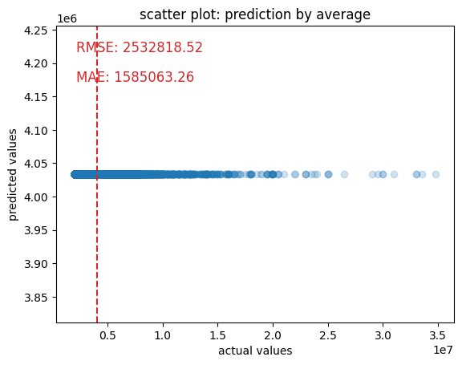

```python
mean_train = np.mean(target_train)
mean_test = np.full_like(target_test, fill_value = mean_train, dtype=float)

rmse = mean_squared_error(target_test, mean_test)**0.5
mae = mean_absolute_error(target_test, mean_test)

print("mean prediction:", mean_train)


print("RMSE:", rmse)
print("MAE:", mae)

plt.scatter(target_test, mean_test, color="tab:blue", alpha = 0.2)
plt.axvline(x = mean_train, color = "tab:red", linestyle='--')

plt.annotate(f'RMSE: {rmse:.2f}', xy=(0.05, 0.95), xycoords='axes fraction', fontsize=12, ha='left', va='top', color="tab:red")
plt.annotate(f'MAE: {mae:.2f}', xy=(0.05, 0.85), xycoords='axes fraction', fontsize=12, ha='left', va='top', color="tab:red")

plt.title('scatter plot: prediction by average')
plt.xlabel('actual values')
plt.ylabel('predicted values')

plt.show()
```

### CatBoost

```python
%%time
model = CatBoostRegressor(loss_function = loss_function, cat_features = cat_features, iterations=100)
```

```
CPU times: total: 0 ns
Wall time: 0 ns
```

```python
kf = KFold(n_splits=3, shuffle=True, random_state = RANDOM_STATE)
```

```python
predictions = cross_val_predict(model, features, target, cv = kf)
```

[output not shown]

[output cut: 99 more lines]

[output not shown]

[output not shown]

[output cut: 94 more lines]

[output not shown]

```python
rmse = mean_squared_error(target, predictions)**0.5
mae = mean_absolute_error(target, predictions)

print("RMSE:", rmse)
print("MAE:", mae)
```

```
RMSE: 990355.2679884017
MAE: 522271.3328678229
```

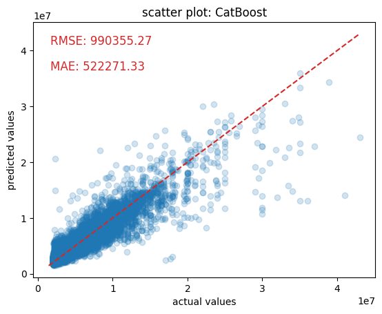

```python
fig, ax = plt.subplots()

ax.scatter(target, predictions, color="tab:blue", alpha = 0.2)

x = np.linspace(min(target.min(), predictions.min()), max(target.max(), predictions.max()), 100)
y = x
ax.plot(x, y, 'r--', color="tab:red")

ax.annotate(f'RMSE: {rmse:.2f}', xy=(0.05, 0.95), xycoords='axes fraction', fontsize=12, ha='left', va='top', color="tab:red")
ax.annotate(f'MAE: {mae:.2f}', xy=(0.05, 0.85), xycoords='axes fraction', fontsize=12, ha='left', va='top', color="tab:red")

ax.set_title('scatter plot: CatBoost')
ax.set_xlabel('actual values')
ax.set_ylabel('predicted values')

plt.show()
```

#### Подбор гиперпарамеров

```python
model = CatBoostRegressor(
    loss_function = loss_function,
    cat_features = cat_features,
    iterations=1300,
    boosting_type="Plain",
    grow_policy="Depthwise",
    min_child_samples=4,
    logging_level = "Silent",
    random_state = RANDOM_STATE,
    depth=11,
    learning_rate=0.1
)
```

```python
predictions = cross_val_predict(model, features, target, cv = kf)
```

```python
model.fit(features, target)

model.save_model(data_root/'models/model_osm.cbm', format='cbm')
```

```python
rmse = mean_squared_error(target, predictions)**0.5
mae = mean_absolute_error(target, predictions)

print("RMSE:", rmse)
print("MAE:", mae)
```

```
RMSE: 858907.9027474977
MAE: 372109.5108361467
```

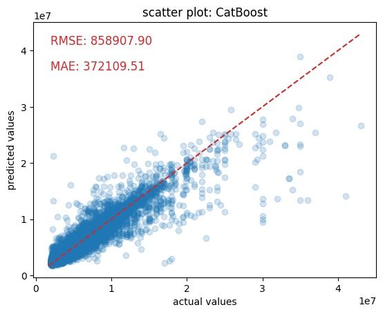

```python
fig, ax = plt.subplots()

ax.scatter(target, predictions, color="tab:blue", alpha = 0.2)

x = np.linspace(min(target.min(), predictions.min()), max(target.max(), predictions.max()), 100)
y = x
ax.plot(x, y, 'r--', color="tab:red")

ax.annotate(f'RMSE: {rmse:.2f}', xy=(0.05, 0.95), xycoords='axes fraction', fontsize=12, ha='left', va='top', color="tab:red")
ax.annotate(f'MAE: {mae:.2f}', xy=(0.05, 0.85), xycoords='axes fraction', fontsize=12, ha='left', va='top', color="tab:red")

ax.set_title('scatter plot: CatBoost')
ax.set_xlabel('actual values')
ax.set_ylabel('predicted values')

plt.show()
```

### Важность признаков по p-value

```python
encoder = OneHotEncoder(drop='first') #удаляем первый столбец чтобы не попасть в дамми-ловушку

features_ohe = pd.DataFrame(encoder.fit_transform(features[cat_features]).toarray(), \
                                  columns=encoder.get_feature_names_out())
```

```python
features_code = features.join(features_ohe).drop(cat_features, axis= 1)
features_code.head()
```

|  | atm_h3_11 | atm_h3_9 | bus_h3_11 | bus_h3_9 | cafe_h3_11 | cafe_h3_9 | car_wash_h3_11 | car_wash_h3_9 | fuel_h3_11 | fuel_h3_9 | health_h3_11 | health_h3_9 | lat | lng | museum_h3_11 | museum_h3_9 | office_h3_11 | office_h3_9 | parking_h3_11 | parking_h3_9 | railway_h3_11 | railway_h3_9 | rooms | square | square_kitchen | subway_h3_11 | subway_h3_9 | toilets_h3_11 | toilets_h3_9 | … |
| --- | --- | --- | --- | --- | --- | --- | --- | --- | --- | --- | --- | --- | --- | --- | --- | --- | --- | --- | --- | --- | --- | --- | --- | --- | --- | --- | --- | --- | --- | --- |
| 0 | False | False | False | False | False | False | False | False | False | False | False | False | 55.012749 | 83.001835 | False | False | False | False | False | False | False | False | 2 | 64.0 | 25.000000 | False | False | False | False | … |
| 1 | False | False | False | False | False | False | False | False | False | False | False | False | 55.024389 | 82.910773 | False | True | False | True | False | False | False | False | 1 | 35.3 | 8.300000 | False | False | False | False | … |
| 2 | False | False | False | False | False | False | False | False | False | False | False | False | 54.985349 | 82.863854 | False | False | False | True | False | False | False | False | 2 | 54.5 | 7.000000 | False | False | False | False | … |
| 3 | False | True | False | False | False | False | False | False | False | False | False | False | 54.870927 | 83.096688 | False | False | False | True | False | False | False | False | 2 | 44.6 | 9.173201 | False | False | False | False | … |
| 4 | False | False | False | False | False | True | False | False | False | False | False | True | 55.112005 | 82.938064 | False | False | False | True | False | False | False | False | 2 | 57.0 | 8.000000 | False | False | False | False | … |

```python
numeric = ['square_kitchen', 'rooms', 'square', 'lat', 'lng']
scaler = StandardScaler()
scaler.fit(features_code[numeric])
```

```
StandardScaler()
```

```python
features_code[numeric] = scaler.transform(features_code[numeric])
```

```python
features_code.head()
```

|  | atm_h3_11 | atm_h3_9 | bus_h3_11 | bus_h3_9 | cafe_h3_11 | cafe_h3_9 | car_wash_h3_11 | car_wash_h3_9 | fuel_h3_11 | fuel_h3_9 | health_h3_11 | health_h3_9 | lat | lng | museum_h3_11 | museum_h3_9 | office_h3_11 | office_h3_9 | parking_h3_11 | parking_h3_9 | railway_h3_11 | railway_h3_9 | rooms | square | square_kitchen | subway_h3_11 | subway_h3_9 | toilets_h3_11 | toilets_h3_9 | … |
| --- | --- | --- | --- | --- | --- | --- | --- | --- | --- | --- | --- | --- | --- | --- | --- | --- | --- | --- | --- | --- | --- | --- | --- | --- | --- | --- | --- | --- | --- | --- |
| 0 | False | False | False | False | False | False | False | False | False | False | False | False | -0.082298 | 0.989011 | False | False | False | False | False | False | False | False | 0.097536 | 0.128314 | 0.064872 | False | False | False | False | … |
| 1 | False | False | False | False | False | False | False | False | False | False | False | False | 0.117386 | -0.508129 | False | True | False | True | False | False | False | False | -0.823076 | -0.979606 | -0.010687 | False | False | False | False | … |
| 2 | False | False | False | False | False | False | False | False | False | False | False | False | -0.552346 | -1.279519 | False | False | False | True | False | False | False | False | 0.097536 | -0.238419 | -0.016569 | False | False | False | False | … |
| 3 | False | True | False | False | False | False | False | False | False | False | False | False | -2.515259 | 2.548478 | False | False | False | True | False | False | False | False | 0.097536 | -0.620593 | -0.006736 | False | False | False | False | … |
| 4 | False | False | False | False | False | True | False | False | False | False | False | True | 1.620441 | -0.059441 | False | False | False | True | False | False | False | False | 0.097536 | -0.141910 | -0.012044 | False | False | False | False | … |

```python
bool_columns = features_code.select_dtypes(include=bool)
features_code_numeric = bool_columns.astype(int)

other_columns = features_code.drop(columns=bool_columns.columns)

features_code = pd.concat([other_columns, features_code_numeric], axis=1)
```

```python
X = sm.add_constant(features_code)

model = sm.OLS(target, features_code)

results = model.fit()

p_values = results.pvalues

p_values[(p_values).round(2)>0.05]
```

```
lng               0.697254
square_kitchen    0.530534
bus_h3_11         0.974591
cafe_h3_11        0.063165
office_h3_11      0.628768
railway_h3_11     0.912551
toilets_h3_11     0.113566
dtype: float64
```

Признаки выше не является статистически значимым при уровне значимости 0.05. Возможно, стоит убрать этот признаки, кроме lng.

### Промежуточный результат

- `Baseline` предсказания средним: `RMSE`: 2532818 руб., `MAE`: 1585063 руб.
- Рассмотрена модель `CatBoost`для предсказания цены на квартиру по исходным данным data и данным c OSM.

`RMSE`: 858908 руб., `MAE`: 372110 руб.

- Важность признаков по p-value для линейной модели - есть слабо значимые признаки, их можно попробовать убрать.
- Построен scatter plot зависимость предсказания и реального значения.

## Предсказания цен на квартиры синтетического датасета

### Загрузка модели и предсказание цены на квартиру

```python
cb_model = CatBoostRegressor(loss_function = 'RMSE', cat_features = cat_features)
```

```python
cb_model.get_params()
```

```
{'loss_function': 'RMSE',
 'cat_features': ['object_type', 'type_of_house', 'floor_first', 'floor_last']}
```

```python
fitt_model = cb_model.load_model(data_root/'models/model_osm.cbm')
```

```python
type(fitt_model)
```

```
catboost.core.CatBoostRegressor
```

```python
fitt_model.get_params()
```

```
{'boosting_type': 'Plain',
 'iterations': 1300,
 'logging_level': 'Silent',
 'loss_function': 'RMSE',
 'grow_policy': 'Depthwise',
 'depth': 11,
 'min_data_in_leaf': 4,
 'random_seed': 2034,
 'learning_rate': 0.1}
```

### Геопространсвенная индексация данных синтетического датасета и добавление пространственных признаков

```python
flats_synth = flats_synth.h3.geo_to_h3(9, set_index=False).h3.geo_to_h3(11, set_index=False)
flats_synth.head()
```

|  | lat | lng | type_of_house | object_type | square_kitchen | floor_first | rooms | square | floor_last | h3_09 | h3_11 |
| --- | --- | --- | --- | --- | --- | --- | --- | --- | --- | --- | --- |
| 0 | 55.010377 | 82.943733 | Кирпичный | Вторичка | 12.340629 | False | 2 | 57.6 | False | 890bb03733bffff | 8b0bb0373394fff |
| 1 | 54.980512 | 82.829227 | Кирпичный | Вторичка | 17.000000 | False | 3 | 120.4 | False | 890bb0ada47ffff | 8b0bb0ada472fff |
| 2 | 54.851438 | 83.040711 | Кирпичный | Вторичка | 8.200000 | False | 2 | 46.0 | True | 890bb03ad73ffff | 8b0bb03ad71afff |
| 3 | 54.991645 | 82.866254 | Кирпичный | Вторичка | 11.000000 | False | 1 | 63.4 | False | 890bb03740bffff | 8b0bb0374099fff |
| 4 | 54.973813 | 82.892176 | Панельный | Вторичка | 0.000000 | False | 0 | 58.0 | False | 890bb03761bffff | 8b0bb037619afff |

```python
geo_features9 = pd.read_csv(data_root /'transformed/geo_features9.csv')
geo_features9.head()
```

|  | h3_09 | parking_h3_9 | subway_h3_9 | cafe_h3_9 | bus_h3_9 | museum_h3_9 | car_wash_h3_9 | health_h3_9 | office_h3_9 | toilets_h3_9 | fuel_h3_9 | atm_h3_9 | railway_h3_9 |
| --- | --- | --- | --- | --- | --- | --- | --- | --- | --- | --- | --- | --- | --- |
| 0 | 890bb034693ffff | False | True | True | False | False | False | False | True | True | False | True | True |
| 1 | 890bb151153ffff | False | False | False | False | False | False | False | False | False | True | False | False |
| 2 | 890bb151e47ffff | False | False | False | False | False | False | False | False | False | False | False | False |
| 3 | 890bb034ca7ffff | False | False | False | False | False | False | False | False | False | False | False | False |
| 4 | 890bb034cd7ffff | False | False | False | False | False | False | False | False | False | False | False | True |

```python
geo_features11 = pd.read_csv(data_root /'transformed/geo_features11.csv')
geo_features11.head()
```

|  | h3_11 | parking_h3_11 | subway_h3_11 | cafe_h3_11 | bus_h3_11 | museum_h3_11 | car_wash_h3_11 | health_h3_11 | office_h3_11 | toilets_h3_11 | fuel_h3_11 | atm_h3_11 | railway_h3_11 |
| --- | --- | --- | --- | --- | --- | --- | --- | --- | --- | --- | --- | --- | --- |
| 0 | 8b0bb0346931fff | False | False | False | False | False | False | False | False | False | False | False | False |
| 1 | 8b0bb151151cfff | False | False | False | False | False | False | False | False | False | False | False | False |
| 2 | 8b0bb151e44afff | False | False | False | False | False | False | False | False | False | False | False | False |
| 3 | 8b0bb034ca51fff | False | False | False | False | False | False | False | False | False | False | False | False |
| 4 | 8b0bb034cd48fff | False | False | False | False | False | False | False | False | False | False | False | False |

```python
data_09 = pd.merge(flats_synth, geo_features9, on='h3_09', how='left')
data_11 = pd.merge(data_09, geo_features11, on='h3_11', how='left')
```

```python
data_11 = data_11.fillna(False)
```

```python
flats_synth = data_11
flats_synth = flats_synth.drop(['h3_09','h3_11'], axis=1)
flats_synth = flats_synth.reindex(sorted(flats_synth.columns), axis=1)
```

```python
flats_synth.duplicated().sum()
```

```
57
```

```python
flats_synth = flats_synth.drop_duplicates()
```

```python
price = fitt_model.predict(flats_synth)
```

```python
flats_synth['price'] = price
```

```python
flats_synth.head()
```

|  | atm_h3_11 | atm_h3_9 | bus_h3_11 | bus_h3_9 | cafe_h3_11 | cafe_h3_9 | car_wash_h3_11 | car_wash_h3_9 | floor_first | floor_last | fuel_h3_11 | fuel_h3_9 | health_h3_11 | health_h3_9 | lat | lng | museum_h3_11 | museum_h3_9 | object_type | office_h3_11 | office_h3_9 | parking_h3_11 | parking_h3_9 | railway_h3_11 | railway_h3_9 | rooms | square | square_kitchen | subway_h3_11 | … |
| --- | --- | --- | --- | --- | --- | --- | --- | --- | --- | --- | --- | --- | --- | --- | --- | --- | --- | --- | --- | --- | --- | --- | --- | --- | --- | --- | --- | --- | --- | --- |
| 0 | False | True | False | False | False | True | False | False | False | False | False | False | False | True | 55.010377 | 82.943733 | False | False | Вторичка | False | True | False | False | False | False | 2 | 57.6 | 12.340629 | False | … |
| 1 | False | False | False | False | False | False | False | False | False | False | False | False | False | False | 54.980512 | 82.829227 | False | False | Вторичка | False | True | False | False | False | True | 3 | 120.4 | 17.000000 | False | … |
| 2 | False | False | False | False | False | False | False | False | False | True | False | False | False | True | 54.851438 | 83.040711 | False | False | Вторичка | False | False | False | False | False | False | 2 | 46.0 | 8.200000 | False | … |
| 3 | False | False | False | False | False | False | False | False | False | False | False | False | False | False | 54.991645 | 82.866254 | False | False | Вторичка | False | True | False | False | False | False | 1 | 63.4 | 11.000000 | False | … |
| 4 | False | False | False | False | False | False | False | False | False | False | False | False | False | True | 54.973813 | 82.892176 | False | False | Вторичка | False | True | False | False | False | False | 0 | 58.0 | 0.000000 | False | … |

### Динамика цен на квартиры

Информация взята с сайта: https://rosrealt.ru/novosibirsk/cena/?t=dinamika

```python
df = pd.DataFrame({
    'Цена, ₽/м²': [69438, 67147, 81925, 110722, 120903, 137099]
}, index=['2019', '2020', '2021', '2022', '2023', '2024'])

df
```

|  | Цена, ₽/м² |
| --- | --- |
| 2019 | 69438 |
| 2020 | 67147 |
| 2021 | 81925 |
| 2022 | 110722 |
| 2023 | 120903 |
| 2024 | 137099 |

```python
percent_change = round(((df.loc['2024', 'Цена, ₽/м²']-df.loc['2019', 'Цена, ₽/м²'])/df.loc['2019', 'Цена, ₽/м²'])*100,1)
```

```python
print('Квартиры в Новосибирске с 2019 по 2024 подоражали на',  percent_change, '%')
```

```
Квартиры в Новосибирске с 2019 по 2024 подоражали на 97.4 %
```

```python
start = datetime(2019, 1, 1)
today = datetime.now()
days = (today - start).days
```

```python
day_change = round((df.loc['2024', 'Цена, ₽/м²']-df.loc['2019', 'Цена, ₽/м²'])/days,1)
```

```python
print('Квартиры в Новосибирске с 2019 по 2024 доражали на',  day_change, 'руб. в день.')
```

```
Квартиры в Новосибирске с 2019 по 2024 доражали на 34.2 руб. в день.
```

```python
percent_change = round(((df.loc['2024', 'Цена, ₽/м²']-df.loc['2019', 'Цена, ₽/м²'])/df.loc['2019', 'Цена, ₽/м²'])*100,1)

print('Квартиры в Новосибирске с 2019 по 2024 подоражали на',  percent_change, '%')

start = datetime(2019, 1, 1)
today = datetime.now()
days = (today - start).days

day_change = round((df.loc['2024', 'Цена, ₽/м²']-df.loc['2019', 'Цена, ₽/м²'])/days,1)

print('Квартиры в Новосибирске с 2019 по 2024 доражали на',  day_change, 'руб. в день.')
```

```
Квартиры в Новосибирске с 2019 по 2024 подоражали на 97.4 %
Квартиры в Новосибирске с 2019 по 2024 доражали на 34.2 руб. в день.
```

### Добавим отставание к цене квартиры

```python
np.random.seed(RANDOM_STATE)
flats_synth['random_shift'] = np.random.randint(0, 181, size=len(flats_synth))*day_change*flats_synth['square']
flats_synth.head()
```

|  | atm_h3_11 | atm_h3_9 | bus_h3_11 | bus_h3_9 | cafe_h3_11 | cafe_h3_9 | car_wash_h3_11 | car_wash_h3_9 | floor_first | floor_last | fuel_h3_11 | fuel_h3_9 | health_h3_11 | health_h3_9 | lat | lng | museum_h3_11 | museum_h3_9 | object_type | office_h3_11 | office_h3_9 | parking_h3_11 | parking_h3_9 | railway_h3_11 | railway_h3_9 | rooms | square | square_kitchen | subway_h3_11 | … |
| --- | --- | --- | --- | --- | --- | --- | --- | --- | --- | --- | --- | --- | --- | --- | --- | --- | --- | --- | --- | --- | --- | --- | --- | --- | --- | --- | --- | --- | --- | --- |
| 0 | False | True | False | False | False | True | False | False | False | False | False | False | False | True | 55.010377 | 82.943733 | False | False | Вторичка | False | True | False | False | False | False | 2 | 57.6 | 12.340629 | False | … |
| 1 | False | False | False | False | False | False | False | False | False | False | False | False | False | False | 54.980512 | 82.829227 | False | False | Вторичка | False | True | False | False | False | True | 3 | 120.4 | 17.000000 | False | … |
| 2 | False | False | False | False | False | False | False | False | False | True | False | False | False | True | 54.851438 | 83.040711 | False | False | Вторичка | False | False | False | False | False | False | 2 | 46.0 | 8.200000 | False | … |
| 3 | False | False | False | False | False | False | False | False | False | False | False | False | False | False | 54.991645 | 82.866254 | False | False | Вторичка | False | True | False | False | False | False | 1 | 63.4 | 11.000000 | False | … |
| 4 | False | False | False | False | False | False | False | False | False | False | False | False | False | True | 54.973813 | 82.892176 | False | False | Вторичка | False | True | False | False | False | False | 0 | 58.0 | 0.000000 | False | … |

```python
flats_synth['price'] = flats_synth['price'] - flats_synth['random_shift']
flats_synth.drop(columns=['random_shift'], inplace=True)
flats_synth.head()
```

|  | atm_h3_11 | atm_h3_9 | bus_h3_11 | bus_h3_9 | cafe_h3_11 | cafe_h3_9 | car_wash_h3_11 | car_wash_h3_9 | floor_first | floor_last | fuel_h3_11 | fuel_h3_9 | health_h3_11 | health_h3_9 | lat | lng | museum_h3_11 | museum_h3_9 | object_type | office_h3_11 | office_h3_9 | parking_h3_11 | parking_h3_9 | railway_h3_11 | railway_h3_9 | rooms | square | square_kitchen | subway_h3_11 | … |
| --- | --- | --- | --- | --- | --- | --- | --- | --- | --- | --- | --- | --- | --- | --- | --- | --- | --- | --- | --- | --- | --- | --- | --- | --- | --- | --- | --- | --- | --- | --- |
| 0 | False | True | False | False | False | True | False | False | False | False | False | False | False | True | 55.010377 | 82.943733 | False | False | Вторичка | False | True | False | False | False | False | 2 | 57.6 | 12.340629 | False | … |
| 1 | False | False | False | False | False | False | False | False | False | False | False | False | False | False | 54.980512 | 82.829227 | False | False | Вторичка | False | True | False | False | False | True | 3 | 120.4 | 17.000000 | False | … |
| 2 | False | False | False | False | False | False | False | False | False | True | False | False | False | True | 54.851438 | 83.040711 | False | False | Вторичка | False | False | False | False | False | False | 2 | 46.0 | 8.200000 | False | … |
| 3 | False | False | False | False | False | False | False | False | False | False | False | False | False | False | 54.991645 | 82.866254 | False | False | Вторичка | False | True | False | False | False | False | 1 | 63.4 | 11.000000 | False | … |
| 4 | False | False | False | False | False | False | False | False | False | False | False | False | False | True | 54.973813 | 82.892176 | False | False | Вторичка | False | True | False | False | False | False | 0 | 58.0 | 0.000000 | False | … |

### Добавление нормально распределенного шума к цене квартиры

```python
mean = 0
std = 0.005

flats_synth['price_noise'] = np.random.normal(mean, std * flats_synth['price'], size=len(flats_synth))
flats_synth['price'] += flats_synth['price_noise']
```

```python
flats_synth.head()
```

|  | atm_h3_11 | atm_h3_9 | bus_h3_11 | bus_h3_9 | cafe_h3_11 | cafe_h3_9 | car_wash_h3_11 | car_wash_h3_9 | floor_first | floor_last | fuel_h3_11 | fuel_h3_9 | health_h3_11 | health_h3_9 | lat | lng | museum_h3_11 | museum_h3_9 | object_type | office_h3_11 | office_h3_9 | parking_h3_11 | parking_h3_9 | railway_h3_11 | railway_h3_9 | rooms | square | square_kitchen | subway_h3_11 | … |
| --- | --- | --- | --- | --- | --- | --- | --- | --- | --- | --- | --- | --- | --- | --- | --- | --- | --- | --- | --- | --- | --- | --- | --- | --- | --- | --- | --- | --- | --- | --- |
| 0 | False | True | False | False | False | True | False | False | False | False | False | False | False | True | 55.010377 | 82.943733 | False | False | Вторичка | False | True | False | False | False | False | 2 | 57.6 | 12.340629 | False | … |
| 1 | False | False | False | False | False | False | False | False | False | False | False | False | False | False | 54.980512 | 82.829227 | False | False | Вторичка | False | True | False | False | False | True | 3 | 120.4 | 17.000000 | False | … |
| 2 | False | False | False | False | False | False | False | False | False | True | False | False | False | True | 54.851438 | 83.040711 | False | False | Вторичка | False | False | False | False | False | False | 2 | 46.0 | 8.200000 | False | … |
| 3 | False | False | False | False | False | False | False | False | False | False | False | False | False | False | 54.991645 | 82.866254 | False | False | Вторичка | False | True | False | False | False | False | 1 | 63.4 | 11.000000 | False | … |
| 4 | False | False | False | False | False | False | False | False | False | False | False | False | False | True | 54.973813 | 82.892176 | False | False | Вторичка | False | True | False | False | False | False | 0 | 58.0 | 0.000000 | False | … |

```python
flats_synth.drop(columns=['price_noise'], inplace=True)
flats_synth.head()
```

|  | atm_h3_11 | atm_h3_9 | bus_h3_11 | bus_h3_9 | cafe_h3_11 | cafe_h3_9 | car_wash_h3_11 | car_wash_h3_9 | floor_first | floor_last | fuel_h3_11 | fuel_h3_9 | health_h3_11 | health_h3_9 | lat | lng | museum_h3_11 | museum_h3_9 | object_type | office_h3_11 | office_h3_9 | parking_h3_11 | parking_h3_9 | railway_h3_11 | railway_h3_9 | rooms | square | square_kitchen | subway_h3_11 | … |
| --- | --- | --- | --- | --- | --- | --- | --- | --- | --- | --- | --- | --- | --- | --- | --- | --- | --- | --- | --- | --- | --- | --- | --- | --- | --- | --- | --- | --- | --- | --- |
| 0 | False | True | False | False | False | True | False | False | False | False | False | False | False | True | 55.010377 | 82.943733 | False | False | Вторичка | False | True | False | False | False | False | 2 | 57.6 | 12.340629 | False | … |
| 1 | False | False | False | False | False | False | False | False | False | False | False | False | False | False | 54.980512 | 82.829227 | False | False | Вторичка | False | True | False | False | False | True | 3 | 120.4 | 17.000000 | False | … |
| 2 | False | False | False | False | False | False | False | False | False | True | False | False | False | True | 54.851438 | 83.040711 | False | False | Вторичка | False | False | False | False | False | False | 2 | 46.0 | 8.200000 | False | … |
| 3 | False | False | False | False | False | False | False | False | False | False | False | False | False | False | 54.991645 | 82.866254 | False | False | Вторичка | False | True | False | False | False | False | 1 | 63.4 | 11.000000 | False | … |
| 4 | False | False | False | False | False | False | False | False | False | False | False | False | False | True | 54.973813 | 82.892176 | False | False | Вторичка | False | True | False | False | False | False | 0 | 58.0 | 0.000000 | False | … |

```python
flats_synth.to_csv(data_root /"transformed/flats_synth_price.csv", index=False)
```

### Оценка моделей предсказания для синтетического датасета

Построим простую модель предсказания цены синтетического датасета.

#### Baseline: предсказание средним

```python
data = flats_synth
```

```python
features = data.drop('price', axis=1)
target = data['price']
```

```python
features.describe()
```

|  | lat | lng | rooms | square | square_kitchen |
| --- | --- | --- | --- | --- | --- |
| count | 8943.000000 | 8943.000000 | 8943.000000 | 8943.000000 | 8943.000000 |
| mean | 55.016549 | 82.943331 | 2.020351 | 59.575741 | 9.400404 |
| std | 0.057725 | 0.060837 | 1.066157 | 25.893144 | 6.170967 |
| min | 54.809046 | 82.789976 | 0.000000 | 27.100000 | 0.000000 |
| 25% | 54.985858 | 82.902961 | 1.000000 | 43.000000 | 6.000000 |
| 50% | 55.027632 | 82.936675 | 2.000000 | 55.000000 | 8.900000 |
| 75% | 55.048968 | 82.970792 | 3.000000 | 67.850000 | 11.723598 |
| max | 55.179993 | 83.128375 | 5.000000 | 360.200000 | 82.000000 |

```python
features_train, features_test, target_train, target_test  = train_test_split\
(features, target, test_size = 0.25, random_state = RANDOM_STATE)
```

```python
mean_train = np.mean(target_train)
mean_test = np.full_like(target_test, fill_value = mean_train, dtype=float)
```

```python
rmse = mean_squared_error(target_test, mean_test)**0.5
mae = mean_absolute_error(target_test, mean_test)

print("mean prediction:", mean_train)
print("RMSE:", rmse)
print("MAE:", mae)
```

```
mean prediction: 3742987.1900059814
RMSE: 2000607.0531159348
MAE: 1293809.4919449645
```

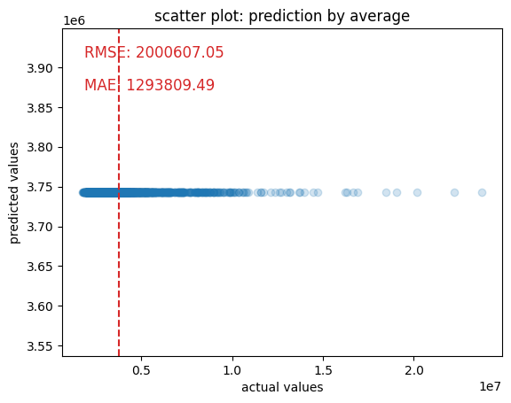

```python
plt.scatter(target_test, mean_test, color="tab:blue", alpha = 0.2)
plt.axvline(x = mean_train, color = "tab:red", linestyle='--')

plt.annotate(f'RMSE: {rmse:.2f}', xy=(0.05, 0.95), xycoords='axes fraction', fontsize=12, ha='left', va='top', color="tab:red")
plt.annotate(f'MAE: {mae:.2f}', xy=(0.05, 0.85), xycoords='axes fraction', fontsize=12, ha='left', va='top', color="tab:red")

plt.title('scatter plot: prediction by average')
plt.xlabel('actual values')
plt.ylabel('predicted values')

plt.show()
```

#### CatBoost

```python
%%time
model = CatBoostRegressor(loss_function = loss_function, cat_features = cat_features, iterations=100)
```

```
CPU times: total: 0 ns
Wall time: 0 ns
```

```python
kf = KFold(n_splits=3, shuffle=True, random_state = RANDOM_STATE)
```

```python
predictions = cross_val_predict(model, features, target, cv = kf)
```

[output not shown]

[output cut: 100 more lines]

[output not shown]

[output not shown]

[output cut: 93 more lines]

[output not shown]

```python
rmse = mean_squared_error(target, predictions)**0.5
mae = mean_absolute_error(target, predictions)

print("RMSE:", rmse)
print("MAE:", mae)
```

```
RMSE: 606737.5074350778
MAE: 339996.07937489776
```

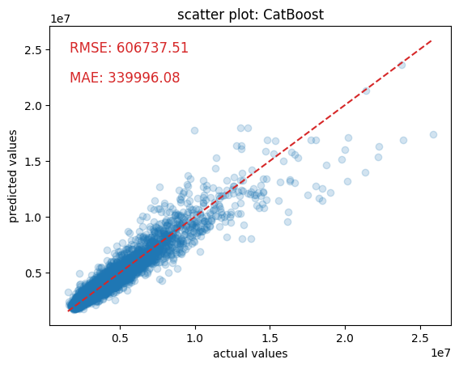

```python
fig, ax = plt.subplots()

ax.scatter(target, predictions, color="tab:blue", alpha = 0.2)

x = np.linspace(min(target.min(), predictions.min()), max(target.max(), predictions.max()), 100)
y = x
ax.plot(x, y, 'r--', color="tab:red")

ax.annotate(f'RMSE: {rmse:.2f}', xy=(0.05, 0.95), xycoords='axes fraction', fontsize=12, ha='left', va='top', color="tab:red")
ax.annotate(f'MAE: {mae:.2f}', xy=(0.05, 0.85), xycoords='axes fraction', fontsize=12, ha='left', va='top', color="tab:red")

ax.set_title('scatter plot: CatBoost')
ax.set_xlabel('actual values')
ax.set_ylabel('predicted values')

plt.show()
```

### Сохранение данных

```python
pq.write_table(pa.Table.from_pandas(data), data_root /'transformed/synth_data.parquet')
```

```python
pq.read_table(data_root /'transformed/synth_data.parquet').to_pandas().head()
```

|  | atm_h3_11 | atm_h3_9 | bus_h3_11 | bus_h3_9 | cafe_h3_11 | cafe_h3_9 | car_wash_h3_11 | car_wash_h3_9 | floor_first | floor_last | fuel_h3_11 | fuel_h3_9 | health_h3_11 | health_h3_9 | lat | lng | museum_h3_11 | museum_h3_9 | object_type | office_h3_11 | office_h3_9 | parking_h3_11 | parking_h3_9 | railway_h3_11 | railway_h3_9 | rooms | square | square_kitchen | subway_h3_11 | … |
| --- | --- | --- | --- | --- | --- | --- | --- | --- | --- | --- | --- | --- | --- | --- | --- | --- | --- | --- | --- | --- | --- | --- | --- | --- | --- | --- | --- | --- | --- | --- |
| 0 | False | True | False | False | False | True | False | False | False | False | False | False | False | True | 55.010377 | 82.943733 | False | False | Вторичка | False | True | False | False | False | False | 2 | 57.6 | 12.340629 | False | … |
| 1 | False | False | False | False | False | False | False | False | False | False | False | False | False | False | 54.980512 | 82.829227 | False | False | Вторичка | False | True | False | False | False | True | 3 | 120.4 | 17.000000 | False | … |
| 2 | False | False | False | False | False | False | False | False | False | True | False | False | False | True | 54.851438 | 83.040711 | False | False | Вторичка | False | False | False | False | False | False | 2 | 46.0 | 8.200000 | False | … |
| 3 | False | False | False | False | False | False | False | False | False | False | False | False | False | False | 54.991645 | 82.866254 | False | False | Вторичка | False | True | False | False | False | False | 1 | 63.4 | 11.000000 | False | … |
| 4 | False | False | False | False | False | False | False | False | False | False | False | False | False | True | 54.973813 | 82.892176 | False | False | Вторичка | False | True | False | False | False | False | 0 | 58.0 | 0.000000 | False | … |

```python
pq.read_table(data_root /'transformed/synth_data.parquet').to_pandas().info()
```

```
<class 'pandas.core.frame.DataFrame'>
Index: 8943 entries, 0 to 8999
Data columns (total 34 columns):
 #   Column          Non-Null Count  Dtype
---  ------          --------------  -----
 0   atm_h3_11       8943 non-null   bool
 1   atm_h3_9        8943 non-null   bool
 2   bus_h3_11       8943 non-null   bool
 3   bus_h3_9        8943 non-null   bool
 4   cafe_h3_11      8943 non-null   bool
 5   cafe_h3_9       8943 non-null   bool
 6   car_wash_h3_11  8943 non-null   bool
 7   car_wash_h3_9   8943 non-null   bool
 8   floor_first     8943 non-null   bool
 9   floor_last      8943 non-null   bool
```

[output cut: 26 more lines]

```python
data['price'] = data['price'].apply(lambda x: round(x, -4))
```

```python
columns = ['lat','lng','type_of_house','object_type','floor_last','floor_first','square','square_kitchen','rooms','price']
data[columns].to_csv(data_root /'transformed/data_geo_course.csv', index=False)
```

```python
pd.read_csv(data_root /'transformed/data_geo_course.csv').head()
```

|  | lat | lng | type_of_house | object_type | floor_last | floor_first | square | square_kitchen | rooms | price |
| --- | --- | --- | --- | --- | --- | --- | --- | --- | --- | --- |
| 0 | 55.010377 | 82.943733 | Кирпичный | Вторичка | False | False | 57.6 | 12.340629 | 2 | 4490000.0 |
| 1 | 54.980512 | 82.829227 | Кирпичный | Вторичка | False | False | 120.4 | 17.000000 | 3 | 5410000.0 |
| 2 | 54.851438 | 83.040711 | Кирпичный | Вторичка | True | False | 46.0 | 8.200000 | 2 | 2590000.0 |
| 3 | 54.991645 | 82.866254 | Кирпичный | Вторичка | False | False | 63.4 | 11.000000 | 1 | 3760000.0 |
| 4 | 54.973813 | 82.892176 | Панельный | Вторичка | False | False | 58.0 | 0.000000 | 0 | 2850000.0 |

```python
pd.read_csv(data_root /'transformed/data_geo_course.csv').info()
```

```
<class 'pandas.core.frame.DataFrame'>
RangeIndex: 8943 entries, 0 to 8942
Data columns (total 10 columns):
 #   Column          Non-Null Count  Dtype
---  ------          --------------  -----
 0   lat             8943 non-null   float64
 1   lng             8943 non-null   float64
 2   type_of_house   8943 non-null   object
 3   object_type     8943 non-null   object
 4   floor_last      8943 non-null   bool
 5   floor_first     8943 non-null   bool
 6   square          8943 non-null   float64
 7   square_kitchen  8943 non-null   float64
 8   rooms           8943 non-null   int64
 9   price           8943 non-null   float64
dtypes: bool(2), float64(5), int64(1), object(2)
memory usage: 576.5+ KB
```

### Промежуточный результат

- добавлен целевой параметр `price` в датасет по предсказаниям модели CatBoost, обученной на исходных данных `data` + данные с OSM
- к параметру `price` добавлен сдвиг к цене на основе динамики цен на квартиры в открытых данных
- к параметру `price` добавлен шум, распределенный нормально со стандартным отклонением 0,005 от цены квартиры
- построена модель baseline предсказания цены средним значением
- построены модели регресии и оценено качество.
- рассмотрена важность признаков п p-value для линейной модели: можно попробовать убрать незначимые признаки для улучения предсказания.
- создан синтетический датасет.

## Результат

**Цель проекта** - создать синтетический датасет, который репрезентирует закрытые данные о продаже недвижимости в Новосибирске, с добавлением геопризнаков. Синтетический датасет (необходимый размер: порядка 9000 квартир) будет использован в рамках курса "Геопространственный анализ данных" https://ods.ai/tracks/geoanalytics-course-spring24.

- Из данных о ценах на квартиры в Новосибирске за 2019 год были извлечены ключевые признаки, такие как площадь кухни, количество комнат, тип объекта, общая площадь, тип дома, географические координаты, стоимость, и информация о первом и последнем этажах. Дубликаты были удалены, пропущенные значения обработаны, данные проверены и проанализированы, а также устранены выбросы и аномалии. Пропуски для количества комнат и площади кухни заполнены средними значениями по группам.
- Из открытых данных реестра многоквартирных домов Новосибирской области был сделан срез для Новосибирска и Краснообска, и данные были геокодированы с помощью `DaData`. Результаты сохранены в `data_geo.csv`. Была проведена геопространственная индексация данных о продаже квартир и многоквартирных домов, сгруппированы по гексагонам, и рассчитано математическое ожидание стоимости квартир для каждого дома, что сохранено в `data_geo_mean`.
- Для создания синтетических данных были использованы 9000 домов из `data_geo_mean`, выбранных с учетом вероятности продажи квартир, с увеличением веса для новостроек. Синтетические квартиры были сгенерированы, используя случайные признаки реальных данных и условные распределения, результаты сохраненны в `flats_synth.csv`.
- Данные c `OpenStreetMap` использовались для создания пространственных признаков для гексагонов 9 и 11 уровней Новосибирска. Модель предсказания цен на квартиры была построена на исходных данных с добавлением пространственных признаков. В синтетический датасет были добавлены предсказанные цены с учетом динамики цен и нормального шума.
- Создан синтетический датасет, построена модель CatBoost для предсказания - оценено качество.